# SNP Filtering Atlantic Croaker (MUN) data set

```r
# # initiate git repository
# system('git config --global user.email "shannon.j.oleary@gmail.com"')
# system('git config --global user.name "shannon"')
source("scr/libraries.R")
source("scr/ggplot.R")
source("scr/VCFfilterstats.R")
source("scr/HaplotypR.R")
source("scr/xtrafunctions.R")
source("scr/genind.R")
```

# SNP filtering

dDocent uses FreeBayes to call SNPs and write a VCF-file `TotalrawSNPs.vcf`. This data set was filtered to remove low quality and artefactual SNP sites, paralogs and low quality individuals based on levels of missing data, minimum/maximum read depth, genotype call rate, and minor allele frequencies. Contigs may contain more than one SNP; the script `rad_haplotyper.pl` was used to create haplotypes for each locus.

## Raw data

### Individuals/Populations sampled

Generate a list of all individuals included in the SNP data set called by FreeBayes in the dDocent pipeline.

```bash
vcfsamplenames data/VCF/temp/TotalRawSNPs.vcf > data/VCF/Ind_raw
```

Use `Ind_raw` file to write text files of individuals in each library and in regional groupings.

```r
# import individuals in raw data set ----
Ind_RAW <- read.table("data/VCF/Ind_raw",
                      header = FALSE, stringsAsFactors = FALSE,
                      col.names = "SAMPLE_ID") %>%
  separate(SAMPLE_ID, into = c("POP", "temp"), sep = "_", remove = FALSE) %>%
  select(-temp)

count(Ind_RAW, POP)

# create files with individuals by population ----
temp <- Ind_RAW %>%
  filter(POP == "AFL") %>%
  select(SAMPLE_ID)

write.table(temp, "data/VCF/Ind_AFL",
            col.names = FALSE, row.names = FALSE, quote = FALSE)

temp <- Ind_RAW %>%
  filter(POP == "BSL") %>%
  select(SAMPLE_ID)

write.table(temp, "data/VCF/Ind_BSL",
            col.names = FALSE, row.names = FALSE, quote = FALSE)

temp <- Ind_RAW %>%
  filter(POP == "JKF") %>%
  select(SAMPLE_ID)

write.table(temp, "data/VCF/Ind_JKF",
            col.names = FALSE, row.names = FALSE, quote = FALSE)

temp <- Ind_RAW %>%
  filter(POP == "SLT") %>%
  select(SAMPLE_ID)

write.table(temp, "data/VCF/Ind_SLT",
            col.names = FALSE, row.names = FALSE, quote = FALSE)

temp <- Ind_RAW %>%
  filter(POP == "ULM") %>%
  select(SAMPLE_ID)

write.table(temp, "data/VCF/Ind_ULM",
            col.names = FALSE, row.names = FALSE, quote = FALSE)
```

### Compare Individual & SNP stats

Use `VCFtools` to create stats files for depth, missing data, heterozygosity and site quality for the raw data.

```bash
vcftools --vcf data/VCF/temp/TotalRawSNPs.vcf --out data/VCF/MUN_raw --depth
vcftools --vcf data/VCF/temp/TotalRawSNPs.vcf --out data/VCF/MUN_raw --site-mean-depth
vcftools --vcf data/VCF/temp/TotalRawSNPs.vcf --out data/VCF/MUN_raw --site-quality
vcftools --vcf data/VCF/temp/TotalRawSNPs.vcf --out data/VCF/MUN_raw --missing-indv
vcftools --vcf data/VCF/temp/TotalRawSNPs.vcf --out data/VCF/MUN_raw --missing-site
vcftools --vcf data/VCF/temp/TotalRawSNPs.vcf --out data/VCF/MUN_raw --het
vcftools --vcf data/VCF/temp/TotalRawSNPs.vcf --out data/VCF/MUN_raw--geno-depth
```

#### Genotype depth distribution

Import genotype depth per locus and individual and format into tidy data set.

```r
gdepth <- read.table("data/VCF/MUN_raw.gdepth",
                         header = TRUE, stringsAsFactors = FALSE) %>%
  unite(col = LOCUS, CHROM, POS, sep = "_", remove = TRUE) %>%
  gather(key = IND, value = GDEPTH, 2:171) %>%
  mutate(MISSING = ifelse(GDEPTH == -1, "missing", "genotyped")) %>%
  mutate(GDEPTH = as.numeric(gsub(-1, 0, GDEPTH))) %>%
  mutate(GDEPTHBIN = cut(GDEPTH,
                         breaks = c(0, 2, 5, 10, 25, 50, 100, 500, max(GDEPTH)),
                         labels = c("<3", "<5", "<10", "<25", "<50", "<100", "<500", ">500")))
```

Create heatmap of genotype depth:

```r
# library(viridis)
ggplot(gdepth, aes(x = IND, y = LOCUS)) +
  geom_tile(aes(fill = GDEPTHBIN)) +
  scale_fill_viridis(direction = -1, option = "viridis",
                     name = 'genotype depth',
                     discrete = TRUE) +
  labs(x = "individual", y = "locus") +
  theme(axis.text.x=element_blank(),
        axis.ticks.x=element_blank(),
        axis.text.y=element_blank(),
        axis.ticks.y=element_blank(),
        legend.position="bottom")
```

#### Visualize raw data stats

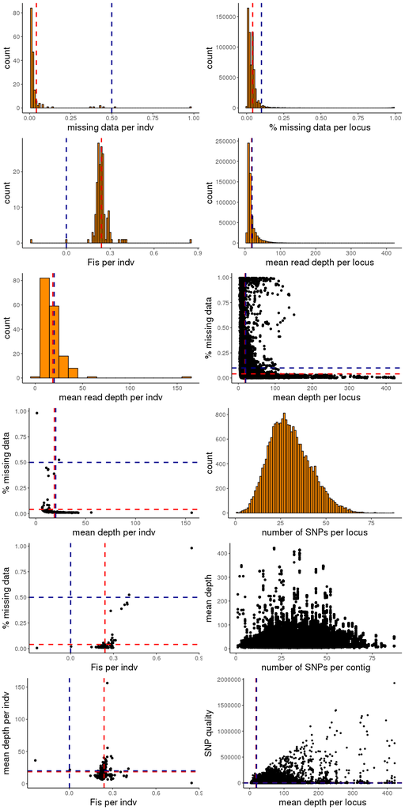

```r
# load stats files ----
ind_stats_raw <- read.ind.stats(dir = "data/VCF", vcf = "MUN_raw")
loc_stats_raw <- read.loc.stats(dir = "data/VCF/", vcf = "MUN_raw")
# plot missing data per indv ----
p1 <- ggplot(ind_stats_raw, aes(x = MISS_MUN_raw)) +
  geom_histogram(binwidth = .01, color = "black", fill = "darkorange") +
  geom_vline(aes(xintercept = mean(MISS_MUN_raw, na.rm = TRUE)),
                 color = "red", linetype = "dashed", size = 1) +
  geom_vline(aes(xintercept = 0.5),
                 color = "darkblue", linetype = "dashed", size = 1) +
  labs(x = "missing data per indv") +
  theme_standard
# plot Fis per indv ----
p2 <- ggplot(ind_stats_raw, aes(x = Fis_MUN_raw)) +
  geom_histogram(binwidth = .01, color = "black", fill = "darkorange") +
  geom_vline(aes(xintercept = mean(Fis_MUN_raw, na.rm = TRUE)),
                 color = "red", linetype = "dashed", size = 1) +
  geom_vline(aes(xintercept = 0),
                 color = "darkblue", linetype = "dashed", size = 1) +
  labs(x = "Fis per indv") +
  theme_standard
# plot read depth per indv ----
p3 <- ggplot(ind_stats_raw, aes(x = MEAN_DEPTH_MUN_raw)) +
  geom_histogram(binwidth = 10, color = "black", fill = "darkorange") +
  geom_vline(aes(xintercept = mean(MEAN_DEPTH_MUN_raw, na.rm = TRUE)),
                 color = "red", linetype = "dashed", size = 1) +
  geom_vline(aes(xintercept = 20),
                 color = "darkblue", linetype = "dashed", size = 1) +
  labs(x = "mean read depth per indv") +
  theme_standard
# plot depth vs missing ----
p4 <- ggplot(ind_stats_raw, aes(x = MEAN_DEPTH_MUN_raw, y = MISS_MUN_raw)) +
  geom_point() +
  geom_vline(aes(xintercept = mean(MEAN_DEPTH_MUN_raw, na.rm = TRUE)),
                 color = "red", linetype = "dashed", size = 1) +
  geom_vline(aes(xintercept = 20),
                 color = "darkblue", linetype = "dashed", size = 1) +
  geom_hline(aes(yintercept = mean(MISS_MUN_raw, na.rm = TRUE)),
                 color = "red", linetype = "dashed", size = 1) +
  geom_hline(aes(yintercept = 0.5),
                 color = "darkblue", linetype = "dashed", size = 1) +
  labs(x = "mean depth per indv", y = "% missing data") +
  theme_standard
# plot Fis vs missing data per indv ----
p5 <- ggplot(ind_stats_raw, aes(x = Fis_MUN_raw, y = MISS_MUN_raw)) +
  geom_point() +
  geom_vline(aes(xintercept = mean(Fis_MUN_raw, na.rm = TRUE)),
                 color = "red", linetype = "dashed", size = 1) +
  geom_vline(aes(xintercept = 0),
                 color = "darkblue", linetype = "dashed", size = 1) +
  geom_hline(aes(yintercept = mean(MISS_MUN_raw, na.rm = TRUE)),
                 color = "red", linetype = "dashed", size = 1) +
  geom_hline(aes(yintercept = 0.5),
                 color = "darkblue", linetype = "dashed", size = 1) +
  labs(x = "Fis per indv", y = "% missing data") +
  theme_standard
# plot Fis vs mean depth per indv ----
p6 <- ggplot(ind_stats_raw, aes(x = Fis_MUN_raw, y = MEAN_DEPTH_MUN_raw)) +
  geom_point() +
  geom_vline(aes(xintercept = mean(Fis_MUN_raw, na.rm = TRUE)),
                 color = "red", linetype = "dashed", size = 1) +
  geom_vline(aes(xintercept = 0),
                 color = "darkblue", linetype = "dashed", size = 1) +
  geom_hline(aes(yintercept = mean(MEAN_DEPTH_MUN_raw, na.rm = TRUE)),
                 color = "red", linetype = "dashed", size = 1) +
  geom_hline(aes(yintercept = 20),
                 color = "darkblue", linetype = "dashed", size = 1) +
  labs(x = "Fis per indv", y = "mean depth per indv") +
  theme_standard
# plot distribution missing data per locus ----
p7 <- ggplot(loc_stats_raw, aes(x = MISS_MUN_raw)) +
  geom_histogram(binwidth = 0.01, color = "black", fill = "darkorange") +
  geom_vline(aes(xintercept = mean(MISS_MUN_raw, na.rm = TRUE)),
                 color = "red", linetype = "dashed", size = 1) +
  geom_vline(aes(xintercept = 0.1),
                 color = "darkblue", linetype = "dashed", size = 1) +
  labs(x = "% missing data per locus") +
  theme_standard
# plot distribution mean read depth ----
p8 <- ggplot(loc_stats_raw, aes(x = MEAN_DEPTH_MUN_raw)) +
  geom_histogram(binwidth = 5, color = "black", fill = "darkorange") +
  geom_vline(aes(xintercept = mean(MEAN_DEPTH_MUN_raw, na.rm = TRUE)),
                 color = "red", linetype = "dashed", size = 1) +
  geom_vline(aes(xintercept = 20),
                 color = "darkblue", linetype = "dashed", size = 1) +
  labs(x = "mean read depth per locus") +
  theme_standard
# plot read depth vs missing data ----
p9 <- ggplot(loc_stats_raw, aes(x = MEAN_DEPTH_MUN_raw, y = MISS_MUN_raw)) +
  geom_point() +
  geom_vline(aes(xintercept = mean(MEAN_DEPTH_MUN_raw, na.rm = TRUE)),
                 color = "red", linetype = "dashed", size = 1) +
  geom_vline(aes(xintercept = 20),
                 color = "darkblue", linetype = "dashed", size = 1) +
  geom_hline(aes(yintercept = mean(MISS_MUN_raw, na.rm = TRUE)),
                 color = "red", linetype = "dashed", size = 1) +
  geom_hline(aes(yintercept = 0.1),
                 color = "darkblue", linetype = "dashed", size = 1) +
  labs(x = "mean depth per locus", y = "% missing data") +
  theme_standard
# plot no of SNPs per locus ----
p10 <- loc_stats_raw %>%
  count(CHR) %>%
  ggplot(aes(x = n)) +
  geom_histogram(binwidth = 1, color = "black", fill = "darkorange") +
  labs(x = "number of SNPs per locus") +
  theme_standard
temp <- loc_stats_raw %>%
  count(CHR)
# plot number of SNPs per contig vs. mean depth ----
p11 <- left_join(temp, loc_stats_raw) %>%
  ggplot() +
  geom_point(aes(x = n, y = MEAN_DEPTH_MUN_raw)) +
  labs(x = "number of SNPs per contig", y = "mean depth") +
  theme_standard
# plot depth vs SNP quality ----
site_qual <- read.table("data/VCF/MUN_raw.lqual",
                        header = TRUE, stringsAsFactors = FALSE) %>%
  mutate(PROB = 10^(-QUAL/10))
temp <- data.frame(loc_stats_raw$MEAN_DEPTH_MUN_raw, site_qual$QUAL) %>%
  rename(depth = loc_stats_raw.MEAN_DEPTH_MUN_raw, qual = site_qual.QUAL)
p12 <- ggplot(temp, aes(x = depth, y = qual)) +
  geom_point(size = 1) +
  geom_vline(aes(xintercept = mean(depth, na.rm = TRUE)),
                 color = "red", linetype = "dashed", size = 1) +
  geom_vline(aes(xintercept = 20),
                 color = "darkblue", linetype = "dashed", size = 1) +
  geom_hline(aes(yintercept = mean(qual, na.rm = TRUE)),
                 color = "red", linetype = "dashed", size = 1) +
  geom_hline(aes(yintercept = 20),
                 color = "darkblue", linetype = "dashed", size = 1) +
  labs(x = "mean depth per locus", y = "SNP quality") +
  theme_standard
m1 <- multiplot(p1, p2, p3, p4, p5, p6, p7, p8, p9, p10, p11, p12, cols=2)
```

## Choose threshold values for quality score, coverage, missing data, minor alleles and mapping/variant calling artifacts

### Filter 0: Remove LQ individuals

```r
# remove LQ individuals
LQind <- ind_stats_raw %>%
  filter(MISS_MUN_raw > 0.95) %>%
  select(INDV)
View(LQind)
# write file
write.table(LQind, "data/VCF/LQ_raw.ind",
            col.names = FALSE, row.names = FALSE, quote = FALSE)
```

Remove low quality individuals.

```bash
# filter quality score (change input file if indv filtered)
vcftools --vcf data/VCF/temp/TotalRawSNPs.vcf --out data/VCF/temp/MUN.F0 --remove data/VCF/LQ_raw.ind --recode --recode-INFO-all

# query stats
vcftools --vcf data/VCF/temp/MUN.F0.recode.vcf --out data/VCF/MUN.F0 --depth
vcftools --vcf data/VCF/temp/MUN.F0.recode.vcf --out data/VCF/MUN.F0 --site-mean-depth
vcftools --vcf data/VCF/temp/MUN.F0.recode.vcf --out data/VCF/MUN.F0 --missing-indv
vcftools --vcf data/VCF/temp/MUN.F0.recode.vcf --out data/VCF/MUN.F0 --missing-site
vcftools --vcf data/VCF/temp/MUN.F0.recode.vcf --out data/VCF/MUN.F0 --het
```

```
VCFtools - 0.1.15
(C) Adam Auton and Anthony Marcketta 2009

Parameters as interpreted:
    --vcf data/VCF/temp/TotalRawSNPs.vcf
    --remove data/VCF/LQ_raw.ind
    --recode-INFO-all
    --out data/VCF/temp/MUN.F0
    --recode

Excluding individuals in 'exclude' list
After filtering, kept 169 out of 170 Individuals
Outputting VCF file...
After filtering, kept 638538 out of a possible 638538 Sites
Run Time = 444.00 seconds

VCFtools - 0.1.15
(C) Adam Auton and Anthony Marcketta 2009

Parameters as interpreted:
    --vcf data/VCF/temp/MUN.F0.recode.vcf
    --depth
    --out data/VCF/MUN.F0

After filtering, kept 169 out of 169 Individuals
Outputting Mean Depth by Individual
After filtering, kept 638538 out of a possible 638538 Sites
Run Time = 34.00 seconds

VCFtools - 0.1.15
(C) Adam Auton and Anthony Marcketta 2009

Parameters as interpreted:
    --vcf data/VCF/temp/MUN.F0.recode.vcf
    --out data/VCF/MUN.F0
    --site-mean-depth

After filtering, kept 169 out of 169 Individuals
Outputting Depth for Each Site
After filtering, kept 638538 out of a possible 638538 Sites
```

[output cut: 26 more lines]

```
Run Time = 31.00 seconds

VCFtools - 0.1.15
(C) Adam Auton and Anthony Marcketta 2009

Parameters as interpreted:
    --vcf data/VCF/temp/MUN.F0.recode.vcf
    --het
    --out data/VCF/MUN.F0

After filtering, kept 169 out of 169 Individuals
Outputting Individual Heterozygosity
    Individual Heterozygosity: Only using biallelic SNPs.
After filtering, kept 638538 out of a possible 638538 Sites
Run Time = 27.00 seconds
```

Visualize stats:

```r
# load stats files ----
ind_stats_F0 <- read.ind.stats(dir = "data/VCF", vcf = "MUN.F0") %>%
  separate(INDV, into = c("SP", "LIB", "SAMPLE_ID"), sep = "_", remove = FALSE)
loc_stats_F0 <- read.loc.stats(dir = "data/VCF/", vcf = "MUN.F0")
```

### Filter 1: Confidence in SNP call

The QUAL column of a VCF file is a phred based score indicating the probability that the variant shown in the ALT column is wrong. Given the Phred quality score (Q), and the probability that a base is incorrectly called (P), Q = -10(Log10P).

A quality score of 20 indicates, a 1 in 100 chance that the SNP site has been called incorrectly (i.e. 99% probability that correct call).

```bash
# filter LQ SNP calls
vcftools --vcf data/VCF/temp/MUN.F0.recode.vcf --out data/VCF/temp/MUN.F1 --remove data/VCF/LQ_raw.ind --minQ 20 --minDP 3 --recode --recode-INFO-all

# query stats
vcftools --vcf data/VCF/temp/MUN.F1.recode.vcf --out data/VCF/MUN.F1 --depth
vcftools --vcf data/VCF/temp/MUN.F1.recode.vcf --out data/VCF/MUN.F1 --site-mean-depth
vcftools --vcf data/VCF/temp/MUN.F1.recode.vcf --out data/VCF/MUN.F1 --missing-indv
vcftools --vcf data/VCF/temp/MUN.F1.recode.vcf --out data/VCF/MUN.F1 --missing-site
vcftools --vcf data/VCF/temp/MUN.F1.recode.vcf --out data/VCF/MUN.F1 --het
vcftools --vcf data/VCF/temp/MUN.F1.recode.vcf --out data/VCF/MUN.F1 --geno-depth
```

Analyze stats post-filtering.

```r
# load stats files ----
ind_stats_F1 <- read.ind.stats(dir = "data/VCF", vcf = "MUN.F1")
loc_stats_F1 <- read.loc.stats(dir = "data/VCF/", vcf = "MUN.F1")
```

Data set contains 169 individuals and 495835 SNP sites.

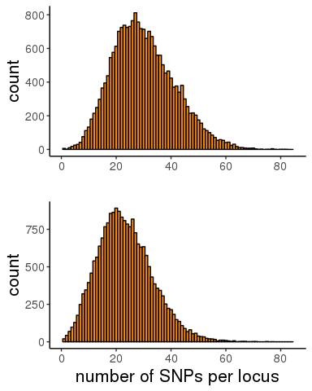

```r
p1 <- loc_stats_raw %>%
  count(CHR) %>%
  ggplot(aes(x = n)) +
  geom_histogram(binwidth = 1, color = "black", fill = "darkorange") +
  scale_x_continuous(limits = c(0, 85)) +
  labs(x = "") +
  theme_standard
p2 <- loc_stats_F1 %>%
  count(CHR) %>%
  ggplot(aes(x = n)) +
  geom_histogram(binwidth = 1, color = "black", fill = "darkorange") +
  labs(x = "number of SNPs per locus") +
  scale_x_continuous(limits = c(0, 85)) +
  theme_standard
m1a <- multiplot(p1, p2, cols=1)
```

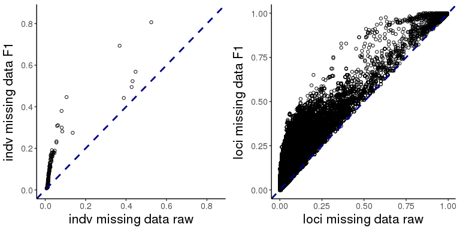

```r
iraw <- read.table("data/VCF/MUN_raw.imiss",
                    header = TRUE, stringsAsFactors = FALSE) %>%
  select(INDV, F_MISS) %>%
  rename(raw = F_MISS)
imiss <- read.table("data/VCF/MUN.F1.imiss",
                    header = TRUE, stringsAsFactors = FALSE) %>%
  select(INDV, F_MISS) %>%
  rename(F1 = F_MISS)
imiss <- left_join(imiss, iraw)
p1 <- ggplot(imiss, aes(x = raw, y = F1)) +
  geom_point(shape = 1) +
  geom_abline(slope = 1, color = "darkblue", linetype = "dashed", size = 1) +
  scale_x_continuous(limits = c(0, 0.85)) +
  scale_y_continuous(limits = c(0, 0.85)) +
  labs(x = "indv missing data raw", y = "indv missing data F1") +
  theme_standard
lraw <- read.table("data/VCF/MUN_raw.lmiss",
                    header = TRUE, stringsAsFactors = FALSE) %>%
  select(CHR, POS, F_MISS) %>%
  rename(raw = F_MISS)
lmiss <- read.table("data/VCF/MUN.F1.lmiss",
                    header = TRUE, stringsAsFactors = FALSE) %>%
  select(CHR, POS, F_MISS) %>%
  rename(F1 = F_MISS)
lmiss <- left_join(lmiss, lraw)
p2 <- ggplot(lmiss, aes(x = raw, y = F1)) +
  geom_point(shape = 1) +
  geom_abline(slope = 1, color = "darkblue", linetype = "dashed", size = 1) +
  labs(x = "loci missing data raw", y = "loci missing data F1") +
  theme_standard
m1b <- multiplot(p1, p2, cols=2)
```

### Filter 2: Genotype call rate and allowed missing data per indv

Remove loci with genotype call rate < 10% and mean read depth per locus across all individuals < 5.

```bash
vcftools --vcf data/VCF/temp/MUN.F1.recode.vcf --out data/VCF/temp/MUN.F2a --max-missing 0.1 --min-meanDP 5 --recode --recode-INFO-all

vcftools --vcf data/VCF/temp/MUN.F2a.recode.vcf --out data/VCF/MUN.F2a --missing-indv
```

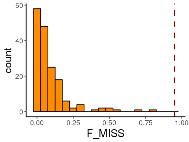

```r
# determine cutoff
imiss <- read.table("data/VCF/MUN.F2a.imiss",
           header = TRUE, stringsAsFactors = FALSE, sep = "\t")
ggplot(imiss, aes(x = F_MISS)) +
  geom_histogram(binwidth = 0.05, color = "black", fill = "darkorange") +
  geom_vline(xintercept = 0.95, color = "darkred", linetype = "dashed", size = 1) +
  theme_standard
```

```r
imiss <- imiss %>%
  filter(F_MISS > 0.95) %>%
  select(INDV)
View(imiss)
write.table(imiss, "data/VCF/F2a_LQ.indv",
            col.names = TRUE, row.names = FALSE, quote = FALSE)
```

Remove flagged individuals, then remove loci with genotype call rate < 30%.

```bash
vcftools --vcf data/VCF/temp/MUN.F2a.recode.vcf --out data/VCF/temp/MUN.F2b --remove data/VCF/F2a_LQ.indv --recode --recode-INFO-all

vcftools --vcf data/VCF/temp/MUN.F2b.recode.vcf --out data/VCF/temp/MUN.F2c --max-missing .3 --recode --recode-INFO-all

vcftools --vcf data/VCF/temp/MUN.F2c.recode.vcf --out data/VCF/MUN.F2c --missing-indv
```

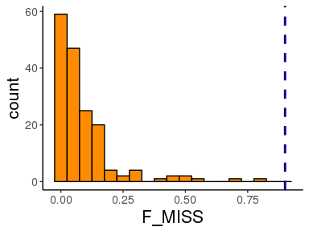

```r
# determine cutoff
imiss <- read.table("data/VCF/MUN.F2c.imiss",
           header = TRUE, stringsAsFactors = FALSE, sep = "\t")
ggplot(imiss, aes(x = F_MISS)) +
  geom_histogram(binwidth = 0.05, color = "black", fill = "darkorange") +
  geom_vline(xintercept = 0.9, color = "darkblue", linetype = "dashed", size = 1) +
  theme_standard
```

```r
imiss <- imiss %>%
  filter(F_MISS > 0.9) %>%
  select(INDV)
write.table(imiss, "data/VCF/F2c_LQ.indv",
            col.names = TRUE, row.names = FALSE, quote = FALSE)
```

Remove flagged individuals and generate missing data stats per locus for all libraries.

```bash
# remove flagged individuals
vcftools --vcf data/VCF/temp/MUN.F2c.recode.vcf --out data/VCF/temp/MUN.F2d --remove data/VCF/F2c_LQ.indv --recode --recode-INFO-all

vcftools --vcf data/VCF/temp/MUN.F2d.recode.vcf --out data/VCF/MUN.F2d --geno-depth

# POP ULM (Upper Laguna Madre)
vcftools --vcf data/VCF/temp/MUN.F2d.recode.vcf --out data/VCF/temp/ULM --keep data/VCF/Ind_ULM  --recode --recode-INFO-all

vcftools --vcf data/VCF/temp/ULM.recode.vcf --out data/VCF/ULM --missing-site

# POP SLT
vcftools --vcf data/VCF/temp/MUN.F2d.recode.vcf --out data/VCF/temp/SLT --keep data/VCF/Ind_SLT  --recode --recode-INFO-all

vcftools --vcf data/VCF/temp/SLT.recode.vcf --out data/VCF/SLT --missing-site

# POP JKF
vcftools --vcf data/VCF/temp/MUN.F2d.recode.vcf --out data/VCF/temp/JKF --keep data/VCF/Ind_JKF  --recode --recode-INFO-all

vcftools --vcf data/VCF/temp/JKF.recode.vcf --out data/VCF/JKF --missing-site

# POP BSL
vcftools --vcf data/VCF/temp/MUN.F2d.recode.vcf --out data/VCF/temp/BSL --keep data/VCF/Ind_BSL  --recode --recode-INFO-all

vcftools --vcf data/VCF/temp/BSL.recode.vcf --out data/VCF/BSL --missing-site

# POP AFL
vcftools --vcf data/VCF/temp/MUN.F2d.recode.vcf --out data/VCF/temp/AFL --keep data/VCF/Ind_AFL  --recode --recode-INFO-all

vcftools --vcf data/VCF/temp/AFL.recode.vcf --out data/VCF/AFL --missing-site
```

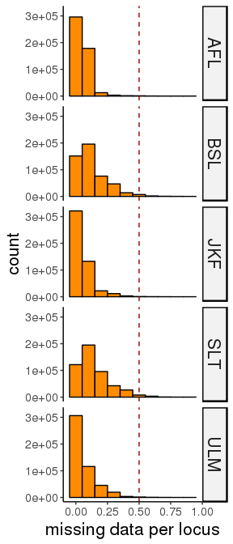

```r
# create empty list
loc_missing <- list()
# import missing data per locus
loc_missing[[1]] <- read.table("data/VCF/ULM.lmiss",
                        header = TRUE, stringsAsFactors = FALSE) %>%
  select(CHR, POS, F_MISS) %>%
  mutate(POP = "ULM")
# import missing data per locus
loc_missing[[2]] <- read.table("data/VCF/SLT.lmiss",
                        header = TRUE, stringsAsFactors = FALSE) %>%
  select(CHR, POS, F_MISS) %>%
  mutate(POP = "SLT")
loc_missing[[3]] <- read.table("data/VCF/JKF.lmiss",
                        header = TRUE, stringsAsFactors = FALSE) %>%
  select(CHR, POS, F_MISS) %>%
  mutate(POP = "JKF")
loc_missing[[4]] <- read.table("data/VCF/BSL.lmiss",
                        header = TRUE, stringsAsFactors = FALSE) %>%
  select(CHR, POS, F_MISS) %>%
  mutate(POP = "BSL")
loc_missing[[5]] <- read.table("data/VCF/AFL.lmiss",
                        header = TRUE, stringsAsFactors = FALSE) %>%
  select(CHR, POS, F_MISS) %>%
  mutate(POP = "AFL")
# create data frame with all information
loc_missing <- ldply(loc_missing, data.frame)
ggplot(loc_missing, aes(x = F_MISS)) +
  geom_histogram(binwidth = .1, color = "black", fill = "darkorange") +
  geom_vline(aes(xintercept = 0.5),
             color = "darkred", linetype = "dashed", size = 0.5) +
  labs(x = "missing data per locus") +
  facet_grid(POP ~ .) +
  theme_standard
```

Flag loci that were not called in > 50% of individuals in a given population.

```r
# identify loci with high missing data in each library
SNPs <- filter(loc_missing, F_MISS > 0.5) %>%
  arrange(CHR, POS)
count(SNPs, POP)
```

| POP | n |
| --- | --- |
| AFL | 672 |
| BSL | 4942 |
| JKF | 836 |
| SLT | 5864 |
| ULM | 1275 |

```r
LQloci <- SNPs %>%
  select(CHR, POS) %>%
  unique()
View(LQloci)
# Write contig/position to file
write.table(LQloci, file = "data/VCF/LQ_F2d.loci",
            col.names= FALSE, row.names = FALSE, quote = FALSE)
```

Remove loci that were not consistently called across sample locations (putative populations.

```bash
vcftools --vcf data/VCF/temp/MUN.F2d.recode.vcf --out data/VCF/temp/MUN.F2e --exclude-positions data/VCF/LQ_F2d.loci --recode --recode-INFO-all

vcftools --vcf data/VCF/temp/MUN.F2e.recode.vcf --out data/VCF/MUN.F2e --missing-indv
```

Identify individuals with > 70% missing data

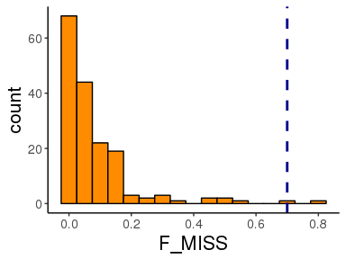

```r
# determine cutoff
imiss <- read.table("data/VCF/MUN.F2e.imiss",
           header = TRUE, stringsAsFactors = FALSE, sep = "\t")
ggplot(imiss, aes(x = F_MISS)) +
  geom_histogram(binwidth = 0.05, color = "black", fill = "darkorange") +
  geom_vline(xintercept = 0.7, color = "darkblue", linetype = "dashed", size = 1) +
  theme_standard
```

```r
imiss <- imiss %>%
  filter(F_MISS > 0.7) %>%
  select(INDV)
View(imiss)
# ggplot(imiss, aes(x = F_MISS)) +
#   geom_histogram()
write.table(imiss, "data/VCF/F2e_LQ.indv",
            col.names = FALSE, row.names = FALSE, quote = FALSE)
```

Remove flagged individuals

```bash
vcftools --vcf data/VCF/temp/MUN.F2e.recode.vcf --out data/VCF/temp/MUN.F2 --remove data/VCF/F2e_LQ.indv --recode --recode-INFO-all

vcftools --vcf data/VCF/temp/MUN.F2.recode.vcf --out data/VCF/MUN.F2 --depth
vcftools --vcf data/VCF/temp/MUN.F2.recode.vcf --out data/VCF/MUN.F2 --site-mean-depth
vcftools --vcf data/VCF/temp/MUN.F2.recode.vcf --out data/VCF/MUN.F2 --missing-indv
vcftools --vcf data/VCF/temp/MUN.F2.recode.vcf --out data/VCF/MUN.F2 --missing-site
vcftools --vcf data/VCF/temp/MUN.F2.recode.vcf --out data/VCF/MUN.F2 --het
vcftools --vcf data/VCF/temp/MUN.F2.recode.vcf --out data/VCF/MUN.F2 --site-quality
```

Analyze stats post-filtering:

```r
# load stats files ----
ind_stats_F2 <- read.ind.stats(dir = "data/VCF", vcf = "MUN.F2") %>%
  separate(INDV, into = c("SP", "LIB", "SAMPLE_ID"), sep = "_", remove = FALSE)
loc_stats_F2 <- read.loc.stats(dir = "data/VCF/", vcf = "MUN.F2")
```

Compare change in missing data of loci and individuals.

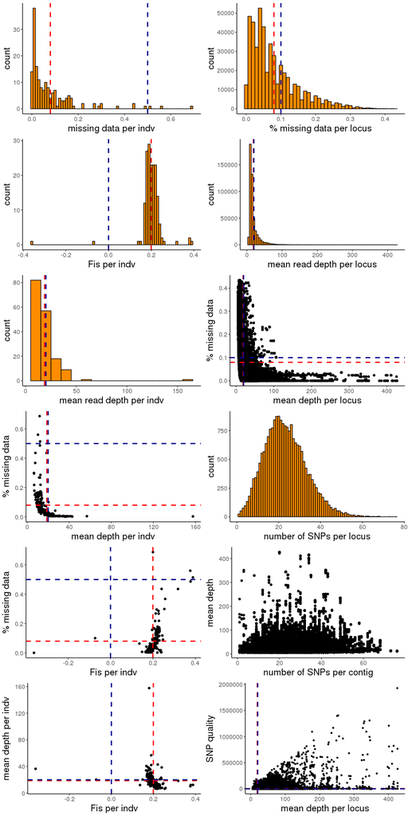

```r
# plot missing data per indv ----
p1 <- ggplot(ind_stats_F2, aes(x = MISS_MUN.F2)) +
  geom_histogram(binwidth = .01, color = "black", fill = "darkorange") +
  geom_vline(aes(xintercept = mean(MISS_MUN.F2, na.rm = TRUE)),
                 color = "red", linetype = "dashed", size = 1) +
  geom_vline(aes(xintercept = 0.5),
                 color = "darkblue", linetype = "dashed", size = 1) +
  labs(x = "missing data per indv") +
  theme_standard
# plot Fis per indv ----
p2 <- ggplot(ind_stats_F2, aes(x = Fis_MUN.F2)) +
  geom_histogram(binwidth = .01, color = "black", fill = "darkorange") +
  geom_vline(aes(xintercept = mean(Fis_MUN.F2, na.rm = TRUE)),
                 color = "red", linetype = "dashed", size = 1) +
  geom_vline(aes(xintercept = 0),
                 color = "darkblue", linetype = "dashed", size = 1) +
  labs(x = "Fis per indv") +
  theme_standard
# plot read depth per indv ----
p3 <- ggplot(ind_stats_F2, aes(x = MEAN_DEPTH_MUN.F2)) +
  geom_histogram(binwidth = 10, color = "black", fill = "darkorange") +
  geom_vline(aes(xintercept = mean(MEAN_DEPTH_MUN.F2, na.rm = TRUE)),
                 color = "red", linetype = "dashed", size = 1) +
  geom_vline(aes(xintercept = 20),
                 color = "darkblue", linetype = "dashed", size = 1) +
  labs(x = "mean read depth per indv") +
  theme_standard
# plot depth vs missing ----
p4 <- ggplot(ind_stats_F2, aes(x = MEAN_DEPTH_MUN.F2, y = MISS_MUN.F2)) +
  geom_point() +
  geom_vline(aes(xintercept = mean(MEAN_DEPTH_MUN.F2, na.rm = TRUE)),
                 color = "red", linetype = "dashed", size = 1) +
  geom_vline(aes(xintercept = 20),
                 color = "darkblue", linetype = "dashed", size = 1) +
  geom_hline(aes(yintercept = mean(MISS_MUN.F2, na.rm = TRUE)),
                 color = "red", linetype = "dashed", size = 1) +
  geom_hline(aes(yintercept = 0.5),
                 color = "darkblue", linetype = "dashed", size = 1) +
  labs(x = "mean depth per indv", y = "% missing data") +
  theme_standard
# plot Fis vs missing data per indv ----
p5 <- ggplot(ind_stats_F2, aes(x = Fis_MUN.F2, y = MISS_MUN.F2)) +
  geom_point() +
  geom_vline(aes(xintercept = mean(Fis_MUN.F2, na.rm = TRUE)),
                 color = "red", linetype = "dashed", size = 1) +
  geom_vline(aes(xintercept = 0),
                 color = "darkblue", linetype = "dashed", size = 1) +
  geom_hline(aes(yintercept = mean(MISS_MUN.F2, na.rm = TRUE)),
                 color = "red", linetype = "dashed", size = 1) +
  geom_hline(aes(yintercept = 0.5),
                 color = "darkblue", linetype = "dashed", size = 1) +
  labs(x = "Fis per indv", y = "% missing data") +
  theme_standard
# plot Fis vs mean depth per indv ----
p6 <- ggplot(ind_stats_F2, aes(x = Fis_MUN.F2, y = MEAN_DEPTH_MUN.F2)) +
  geom_point() +
  geom_vline(aes(xintercept = mean(Fis_MUN.F2, na.rm = TRUE)),
                 color = "red", linetype = "dashed", size = 1) +
  geom_vline(aes(xintercept = 0),
                 color = "darkblue", linetype = "dashed", size = 1) +
  geom_hline(aes(yintercept = mean(MEAN_DEPTH_MUN.F2, na.rm = TRUE)),
                 color = "red", linetype = "dashed", size = 1) +
  geom_hline(aes(yintercept = 20),
                 color = "darkblue", linetype = "dashed", size = 1) +
  labs(x = "Fis per indv", y = "mean depth per indv") +
  theme_standard
# plot distribution missing data per locus ----
p7 <- ggplot(loc_stats_F2, aes(x = MISS_MUN.F2)) +
  geom_histogram(binwidth = 0.01, color = "black", fill = "darkorange") +
  geom_vline(aes(xintercept = mean(MISS_MUN.F2, na.rm = TRUE)),
                 color = "red", linetype = "dashed", size = 1) +
  geom_vline(aes(xintercept = 0.1),
                 color = "darkblue", linetype = "dashed", size = 1) +
  labs(x = "% missing data per locus") +
  theme_standard
# plot distribution mean read depth ----
p8 <- ggplot(loc_stats_F2, aes(x = MEAN_DEPTH_MUN.F2)) +
  geom_histogram(binwidth = 5, color = "black", fill = "darkorange") +
  geom_vline(aes(xintercept = mean(MEAN_DEPTH_MUN.F2, na.rm = TRUE)),
                 color = "red", linetype = "dashed", size = 1) +
  geom_vline(aes(xintercept = 20),
                 color = "darkblue", linetype = "dashed", size = 1) +
  labs(x = "mean read depth per locus") +
  theme_standard
# plot read depth vs missing data ----
p9 <- ggplot(loc_stats_F2, aes(x = MEAN_DEPTH_MUN.F2, y = MISS_MUN.F2)) +
  geom_point() +
  geom_vline(aes(xintercept = mean(MEAN_DEPTH_MUN.F2, na.rm = TRUE)),
                 color = "red", linetype = "dashed", size = 1) +
  geom_vline(aes(xintercept = 20),
                 color = "darkblue", linetype = "dashed", size = 1) +
  geom_hline(aes(yintercept = mean(MISS_MUN.F2, na.rm = TRUE)),
                 color = "red", linetype = "dashed", size = 1) +
  geom_hline(aes(yintercept = 0.1),
                 color = "darkblue", linetype = "dashed", size = 1) +
  labs(x = "mean depth per locus", y = "% missing data") +
  theme_standard
# plot no of SNPs per locus ----
p10 <- loc_stats_F2 %>%
  count(CHR) %>%
  ggplot(aes(x = n)) +
  geom_histogram(binwidth = 1, color = "black", fill = "darkorange") +
  labs(x = "number of SNPs per locus") +
  theme_standard
temp <- loc_stats_F2 %>%
  count(CHR)
# plot number of SNPs per contig vs. mean depth ----
p11 <- left_join(temp, loc_stats_F2) %>%
  ggplot() +
  geom_point(aes(x = n, y = MEAN_DEPTH_MUN.F2)) +
  labs(x = "number of SNPs per contig", y = "mean depth") +
  theme_standard
# plot depth vs SNP quality ----
site_qual <- read.table("data/VCF/MUN.F2.lqual",
                        header = TRUE, stringsAsFactors = FALSE) %>%
  mutate(PROB = 10^(-QUAL/10))
temp <- data.frame(loc_stats_F2$MEAN_DEPTH_MUN.F2, site_qual$QUAL) %>%
  rename(depth = loc_stats_F2.MEAN_DEPTH_MUN.F2, qual = site_qual.QUAL)
p12 <- ggplot(temp, aes(x = depth, y = qual)) +
  geom_point(size = 1) +
  geom_vline(aes(xintercept = mean(depth, na.rm = TRUE)),
                 color = "red", linetype = "dashed", size = 1) +
  geom_vline(aes(xintercept = 20),
                 color = "darkblue", linetype = "dashed", size = 1) +
  geom_hline(aes(yintercept = mean(qual, na.rm = TRUE)),
                 color = "red", linetype = "dashed", size = 1) +
  geom_hline(aes(yintercept = 20),
                 color = "darkblue", linetype = "dashed", size = 1) +
  labs(x = "mean depth per locus", y = "SNP quality") +
  theme_standard
m2 <- multiplot(p1, p2, p3, p4, p5, p6, p7, p8, p9, p10, p11, p12, cols=2)
```

### Filter 3: Remove loci with inconsistent coverage

Compare distribution of depth coverage per locus per library. Identify loci that have low coverage and/or high variance in a given library (compared to other libraries).

Identify loci with large variance in mean depth across libraries and/or individuals:

```r
# mean depth across all individuals
depth_comp <- read.table("data/VCF/MUN.F2.ldepth.mean",
                   header = TRUE, stringsAsFactors = FALSE) %>%
  distinct(CHROM, .keep_all = TRUE) %>%
  select(-POS) %>%
  mutate(STD_DEPTH = sqrt(VAR_DEPTH),
         COEFF_VAR = STD_DEPTH/MEAN_DEPTH*100)
```

Compare mean across all individual to mean weighted by library and standard deviation of mean across all individual to mean of mean depth per library (linear regression (w/95% CI)):

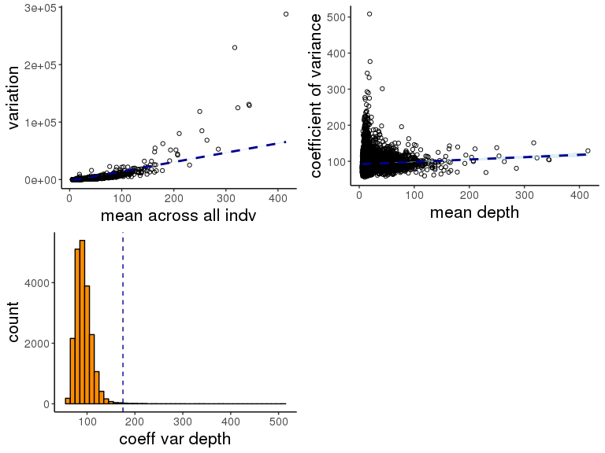

```r
p1 <- ggplot(depth_comp, aes(x = MEAN_DEPTH, y = VAR_DEPTH)) +
  geom_point(shape = 1) +
  geom_smooth(method = lm, se = TRUE,
              color = "darkblue", linetype = "dashed", fill = "lightblue") +
  labs(x = "mean across all indv", y = "variation") +
  theme_standard
p2 <- ggplot(depth_comp, aes(x = MEAN_DEPTH, y = COEFF_VAR)) +
  geom_point(shape = 1) +
  geom_smooth(method = lm, se = TRUE,
              color = "darkblue", linetype = "dashed", fill = "lightblue") +
  labs(x = "mean depth", y = "coefficient of variance") +
  theme_standard
p3 <- ggplot(depth_comp, aes(x = COEFF_VAR)) +
  geom_histogram(binwidth = 10, color = "black", fill = "darkorange") +
  geom_vline(xintercept = 175, color = "darkblue", linetype = "dashed", size = 0.5) +
  labs(x = "coeff var depth") +
  theme_standard
m3 <- multiplot(p1, p3, p2, cols=2)
```

Flag loci that have high variation in mean coverage between individuals and between libraries.

```r
# identify loci high variation in coverage
contigs_var <- depth_comp %>%
  filter(COEFF_VAR > 175)
SNPs_var <- filter(depth_comp, CHROM %in% contigs_var$CHROM) %>%
  distinct(CHROM, POS)
# identify loci with low mean depth across all individuals
SNP_mean <- depth_comp %>%
  filter(MEAN_DEPTH < 10) %>%
  distinct(CHROM, POS)
SNPs <- bind_rows(SNPs_var, SNP_mean) %>%
  distinct(CHROM, POS)
# Write contig/position to text file, use file with vcftools to remove positions from dataset
write.table(SNPs, file = "data/VCF/LQ_F3.loci",
            col.names= FALSE, row.names = FALSE, quote = FALSE)
```

Remove flagged loci.

```bash
vcftools --vcf data/VCF/temp/MUN.F2.recode.vcf --out data/VCF/temp/MUN.F3 --exclude-positions data/VCF/LQ_F3.loci --recode --recode-INFO-all

vcftools --vcf data/VCF/temp/MUN.F3.recode.vcf --out data/VCF/MUN.F3 --depth
vcftools --vcf data/VCF/temp/MUN.F3.recode.vcf --out data/VCF/MUN.F3 --site-mean-depth
vcftools --vcf data/VCF/temp/MUN.F3.recode.vcf --out data/VCF/MUN.F3 --missing-indv
vcftools --vcf data/VCF/temp/MUN.F3.recode.vcf --out data/VCF/MUN.F3 --missing-site
vcftools --vcf data/VCF/temp/MUN.F3.recode.vcf --out data/VCF/MUN.F3 --het
vcftools --vcf data/VCF/temp/MUN.F3.recode.vcf --out data/VCF/MUN.F3 --geno-depth
vcftools --vcf data/VCF/temp/MUN.F3.recode.vcf --out data/VCF/MUN.F3 --site-qual
```

Analyze stats post-filtering:

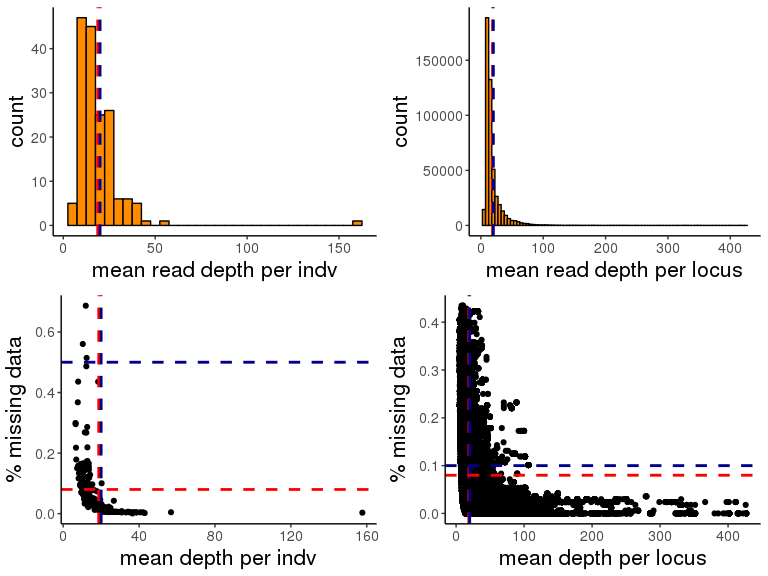

```r
# load stats files ----
ind_stats_F3 <- read.ind.stats(dir = "data/VCF", vcf = "MUN.F3") %>%
  separate(INDV, into = c("SP", "LIB", "SAMPLE_ID"), sep = "_", remove = FALSE)
loc_stats_F3 <- read.loc.stats(dir = "data/VCF/", vcf = "MUN.F3")
# plot read depth per indv ----
p1 <- ggplot(ind_stats_F3, aes(x = MEAN_DEPTH_MUN.F3)) +
  geom_histogram(binwidth = 5, color = "black", fill = "darkorange") +
  geom_vline(aes(xintercept = mean(MEAN_DEPTH_MUN.F3, na.rm = TRUE)),
             color = "red", linetype = "dashed", size = 1) +
  geom_vline(aes(xintercept = 20),
             color = "darkblue", linetype = "dashed", size = 1) +
  labs(x = "mean read depth per indv") +
  theme_standard
# plot depth vs missing ----
p2 <- ggplot(ind_stats_F3, aes(x = MEAN_DEPTH_MUN.F3, y = MISS_MUN.F3)) +
  geom_point() +
  geom_vline(aes(xintercept = mean(MEAN_DEPTH_MUN.F3, na.rm = TRUE)),
             color = "red", linetype = "dashed", size = 1) +
  geom_vline(aes(xintercept = 20),
             color = "darkblue", linetype = "dashed", size = 1) +
  geom_hline(aes(yintercept = mean(MISS_MUN.F3, na.rm = TRUE)),
             color = "red", linetype = "dashed", size = 1) +
  geom_hline(aes(yintercept = 0.5),
             color = "darkblue", linetype = "dashed", size = 1) +
  labs(x = "mean depth per indv", y = "% missing data") +
  theme_standard
# plot distribution mean read depth ----
p3 <- ggplot(loc_stats_F3, aes(x = MEAN_DEPTH_MUN.F3)) +
  geom_histogram(binwidth = 5, color = "black", fill = "darkorange") +
  geom_vline(aes(xintercept = mean(MEAN_DEPTH_MUN.F3, na.rm = TRUE)),
             color = "red", linetype = "dashed", size = 1) +
  geom_vline(aes(xintercept = 20),
             color = "darkblue", linetype = "dashed", size = 1) +
  labs(x = "mean read depth per locus") +
  theme_standard
# plot read depth vs missing data ----
p4 <- ggplot(loc_stats_F3, aes(x = MEAN_DEPTH_MUN.F3, y = MISS_MUN.F3)) +
  geom_point() +
  geom_vline(aes(xintercept = mean(MEAN_DEPTH_MUN.F3, na.rm = TRUE)),
             color = "red", linetype = "dashed", size = 1) +
  geom_vline(aes(xintercept = 20),
             color = "darkblue", linetype = "dashed", size = 1) +
  geom_hline(aes(yintercept = mean(MISS_MUN.F3, na.rm = TRUE)),
             color = "red", linetype = "dashed", size = 1) +
  geom_hline(aes(yintercept = 0.1),
             color = "darkblue", linetype = "dashed", size = 1) +
  labs(x = "mean depth per locus", y = "% missing data") +
  theme_standard
m3 <- multiplot(p1, p2, p3, p4, cols=2)
```

### Filter 4: Minimum mean depth and genotype call rate

```bash
vcftools --vcf data/VCF/temp/MUN.F3.recode.vcf --out data/VCF/temp/MUN.F4 --min-meanDP 15 --max-missing 0.75 --recode --recode-INFO-all

# query stats
vcftools --vcf data/VCF/temp/MUN.F4.recode.vcf --out data/VCF/MUN.F4 --depth
vcftools --vcf data/VCF/temp/MUN.F4.recode.vcf --out data/VCF/MUN.F4 --site-mean-depth
vcftools --vcf data/VCF/temp/MUN.F4.recode.vcf --out data/VCF/MUN.F4 --missing-indv
vcftools --vcf data/VCF/temp/MUN.F4.recode.vcf --out data/VCF/MUN.F4 --missing-site
vcftools --vcf data/VCF/temp/MUN.F4.recode.vcf --out data/VCF/MUN.F4 --het
```

Analyze stats post-filtering:

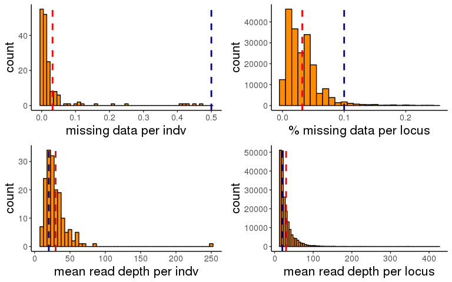

```r
# load stats files ----
ind_stats_F4 <- read.ind.stats(dir = "data/VCF", vcf = "MUN.F4") %>%
  separate(INDV, into = c("SP", "LIB", "SAMPLE_ID"), sep = "_", remove = FALSE)
loc_stats_F4 <- read.loc.stats(dir = "data/VCF/", vcf = "MUN.F4")
# plot missing data per indv ----
p1 <- ggplot(ind_stats_F4, aes(x = MISS_MUN.F4)) +
  geom_histogram(binwidth = .01, color = "black", fill = "darkorange") +
  geom_vline(aes(xintercept = mean(MISS_MUN.F4, na.rm = TRUE)),
             color = "red", linetype = "dashed", size = 1) +
  geom_vline(aes(xintercept = 0.5),
             color = "darkblue", linetype = "dashed", size = 1) +
  labs(x = "missing data per indv") +
  theme_standard
# plot read depth per indv ----
p2 <- ggplot(ind_stats_F4, aes(x = MEAN_DEPTH_MUN.F4)) +
  geom_histogram(binwidth = 5, color = "black", fill = "darkorange") +
  geom_vline(aes(xintercept = mean(MEAN_DEPTH_MUN.F4, na.rm = TRUE)),
             color = "red", linetype = "dashed", size = 1) +
  geom_vline(aes(xintercept = 20),
             color = "darkblue", linetype = "dashed", size = 1) +
  labs(x = "mean read depth per indv") +
  theme_standard
# plot distribution missing data per locus ----
p3 <- ggplot(loc_stats_F4, aes(x = MISS_MUN.F4)) +
  geom_histogram(binwidth = 0.01, color = "black", fill = "darkorange") +
  geom_vline(aes(xintercept = mean(MISS_MUN.F4, na.rm = TRUE)),
             color = "red", linetype = "dashed", size = 1) +
  geom_vline(aes(xintercept = 0.1),
             color = "darkblue", linetype = "dashed", size = 1) +
  labs(x = "% missing data per locus") +
  theme_standard
# plot distribution mean read depth ----
p4 <- ggplot(loc_stats_F4, aes(x = MEAN_DEPTH_MUN.F4)) +
  geom_histogram(binwidth = 5, color = "black", fill = "darkorange") +
  geom_vline(aes(xintercept = mean(MEAN_DEPTH_MUN.F4, na.rm = TRUE)),
             color = "red", linetype = "dashed", size = 1) +
  geom_vline(aes(xintercept = 20),
             color = "darkblue", linetype = "dashed", size = 1) +
  labs(x = "mean read depth per locus") +
  theme_standard
m5 <- multiplot(p1, p2, p3, p4, cols=2)
```

Data set contains 199200 SNP sites.

### Filter 5: Allele balance

AB: Allele balance at heterozygous sites: a number between 0 and 1 representing the ratio of reads showing the reference allele to all reads, considering only reads from individuals called as heterozygous

Allele balance is the ratio of reads for reference allele to all reads, considering only reads from individuals called as heterozygous. Values range from 0 - 1; allele balance (for real loci) should be approx. 0.5. Filter contigs SNPs for which the with allele balance < 0.25 and > 0.75.

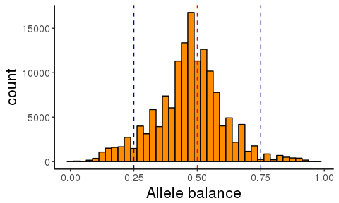

```r
read.table("data/VCF/temp/MUN.F4.AB",
           col.names = "AB", stringsAsFactors = FALSE) %>%
  ggplot(aes(x = AB)) +
  geom_histogram(binwidth = 0.025, color = "black", fill = "darkorange") +
  geom_vline(xintercept = 0.5, color = "red", linetype = "dashed") +
  geom_vline(xintercept = 0.25, color = "darkblue", linetype = "dashed") +
  geom_vline(xintercept = 0.75, color = "darkblue", linetype = "dashed") +
  labs(x = "Allele balance") +
  theme_standard
```

Filter contigs with SNP calls with AB > 0.25, AB > 0.75; retain loci very close to 0 (retain loci that are fixed variants). Remove genotypes if the quality sum of the reference or alternate allele was 0.

Remaining SNPs: 174,356.

### Filter 6: quality/depth ratio

```bash
# site depth
cut -f8 MUN.F5.vcf | grep -oe "DP=[0-9]*" | sed -s 's/DP=//g' > MUN.5.DEPTH

# quality score
mawk '!/#/'  MUN.F5.vcf | cut -f1,2,6 > MUN.F5.loci.qual
```

Compare quality/depth.

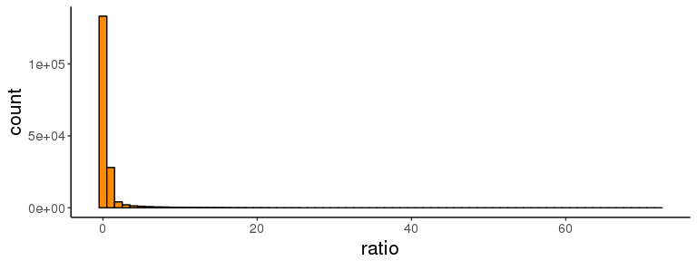

```r
# depth
depth <- read.table("data/VCF/temp/MUN.5.DEPTH",
                    col.names = "depth")
# quality score
qual <- read.table("data/VCF/temp/MUN.F5.loci.qual",
                   col.names = c("locus", "pos", "qual"))
temp <- bind_cols(qual, depth) %>%
  mutate(ratio = qual/depth)
ggplot(temp, aes(x = ratio)) +
  geom_histogram(binwidth = 1, color = "black", fill = "darkorange") +
  theme_standard
```

Remove loci with quality/depth ratio < 0.2

```bash
vcffilter -s -f "QUAL / DP > 0.2" MUN.F5.vcf > MUN.F6.vcf

mawk '!/#/' MUN.F6.vcf | wc -l
```

Remaining SNPs: 72,236.

### Filter 7: mapping quality

Remove loci based on ratio of mapping quality for reference and alternate allele, i.e. sites that have a high discrepancy between the mapping qualities of two alleles.

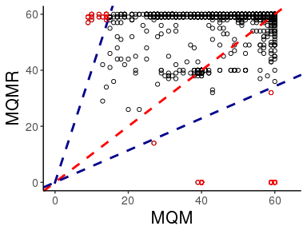

```r
temp <- read.table("data/VCF/temp/MUN.F6.MQM", col.names = "MQM")
mapqual <- read.table("data/VCF/temp/MUN.F6.MQMR", col.names = "MQMR")
mapqual <- bind_cols(mapqual, temp) %>%
  mutate(ratio = MQM/MQMR)
filter <- mapqual %>%
  filter(ratio < 0.25 | ratio > 1.75)
ggplot(mapqual, aes(x = MQM, y = MQMR)) +
  geom_point(shape = 1) +
  geom_abline(intercept = 0, slope = 1, size = 1, color = "red", linetype = "dashed") +
  geom_abline(intercept = 0, slope = 4, size = 1, color = "darkblue", linetype = "dashed") +
  geom_abline(intercept = 0, slope = 0.571, size = 1, color = "darkblue", linetype = "dashed") +
  geom_point(data = filter, aes(x = MQM, y = MQMR), color = "red", shape = 1) +
  scale_x_continuous(limits = c(0, 64)) +
  theme_standard
```

Filter loci with mapping quality ratio < 0.25 and > 1.75.

```bash
vcffilter -s -f "MQM / MQMR > 0.25 & MQM / MQMR < 1.75" MUN.F6.vcf > MUN.F7.vcf

mawk '!/#/' MUN.F7.vcf | wc -l
```

Remaining SNPs: 72,155.

### Filter 8: Strand balance

SRF: Number of reference observations on the forward strand SAF: Number of alternate observations on the forward strand SRR: Number of reference observations on the reverse strand SAR: Number of alternate observations on the reverse strand

Paired end reads should not overlap, and a SNP site should only be covered by either the forward or reverse read (strand).

```r
SAF <- read.table("data/VCF/temp/MUN.F7.SAF",
                  col.names = "SAF")

SAR <- read.table("data/VCF/temp/MUN.F7.SAR",
                  col.names = "SAR")

strands <- bind_cols(SAF, SAR)

SRF <- read.table("data/VCF/temp/MUN.F7.SRF",
                  col.names = "SRF")

strands <- bind_cols(strands, SRF)

SRR <- read.table("data/VCF/temp/MUN.F7.SRR",
                  col.names = "SRR")

strands <- bind_cols(strands, SRR) %>%
  mutate(ratioA = SAF/SAR, ratioR = SRF/SRR)

ggplot(strands, aes(x = SAF, y = SAR)) +
  geom_point(shape = 1) +
  geom_abline(intercept = 0, slope = 0.1, color = "blue", linetype = "dashed", size = 1) +
  geom_abline(intercept = 0, slope = 100, color = "blue", linetype = "dashed", size = 1) +
  theme_standard
```

Remove SNP sites that have > 100x more forward alternate reads than reverse alternate reads and > 100x more forward reverse reads than reverse alternate reads.

```bash
vcffilter -f "SAF / SAR > 100 & SRF / SRR > 100 | SAR / SAF > 100 & SRR / SRF > 100" -s MUN.F7.vcf > MUN.F8.vcf

mawk '!/#/' MUN.F8.vcf | wc -l
```

Number of SNPs remaining: 47,103.

### Filter 9: Properly paired status

PAIRED: Proportion of observed alternate alleles which are supported by properly paired read fragments PAIREDR: Proportion of observed reference alleles which are supported by properly paired read fragments

Identify loci with only unpaired reads mapping to them - an artifact introduced due de novo reference assembly. Compare number of paired reads mapping the reference and the alternate alleles to identify discrepancy in the paired status for reads supporting reference and alternate alleles.

Number of SNPs in data set: 45,667.

### Filter 10: Maximum depth & Quality

Identify distribution of depth (based on original data set) to identify loci with excess coverage.

Original number of individuals in data set is 170 (INFO flags in filtered data set are are based on original number of individuals in data set).

Create file with the original site depth and quality score for each site:

Calculate average depth and standard deviation:

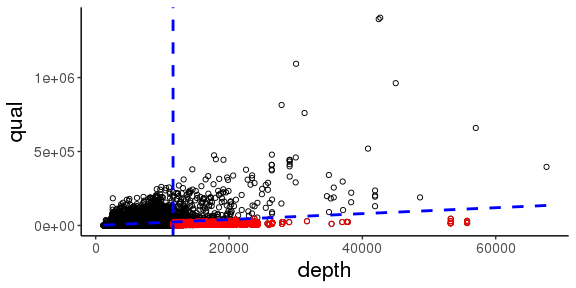

```r
# depth
depth <- read.table("data/VCF/temp/MUN.F10.DEPTH",
                    col.names = "depth")
# quality score
qual <- read.table("data/VCF/temp/MUN.F10.loci.qual",
                   col.names = c("locus", "pos", "qual"))
# mean depth
mean_depth <- mean(depth$depth)
# standard deviation
std <- sd(depth$depth)
# calculate cutoff
cutoff <- sum(mean_depth + (2*std))
# identify SNPs with excess (i.e. depth > mean depth + 1 standard deviation
# and quality score < 2x the depth at that site
df <- bind_cols(qual, depth) %>%
  mutate(qualcutoff = 2*depth)
removeloc <- df %>%
  filter(depth > cutoff) %>%
  filter(qual < 2*depth)
# plot
ggplot(df, aes(x = depth, y = qual)) +
  geom_point(shape = 1) +
  geom_point(data = removeloc, aes(x = depth, y = qual), color = "red", shape = 1) +
  geom_line(data = df, aes(x = depth, y = qualcutoff), color = "blue",  linetype = "dashed", size = 1) +
  geom_vline(xintercept = cutoff, color = "blue", linetype = "dashed", size = 1) +
  theme_standard
```

```r
LQ <- removeloc %>%
  select(locus, pos)
write.table(LQ, "data/VCF/temp/LQ_F10.loci",
            col.names = FALSE, row.names = FALSE, quote = FALSE)
```

Mean depth per locus (across all indivuals) is 4674.6899512 and the standard deviation is 3465.4239393.

Compare the distribution of mean depth per site averaged across individuals to determine cut-off value of sites with excessively high depth indicative of paralogs/multicopy loci.

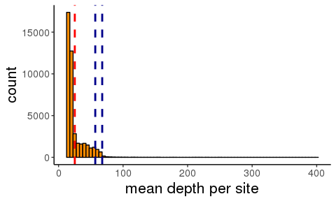

```r
# calculate mean depth per site (177 individuals)
read.table("data/VCF/MUN.F10a.ldepth.mean",
           header = TRUE, stringsAsFactors = FALSE) %>%
  ggplot(aes(x = MEAN_DEPTH)) +
  geom_histogram(binwidth = 5, color = "black", fill = "darkorange") +
  geom_vline(aes(xintercept = mean(MEAN_DEPTH, na.rm = TRUE)),
                 color = "red", linetype = "dashed", size = 1) +
  geom_vline(aes(xintercept = quantile(MEAN_DEPTH, .95)),
                 color = "darkblue", linetype = "dashed", size = 1) +
  geom_vline(aes(xintercept = quantile(MEAN_DEPTH, .99)),
                 color = "darkblue", linetype = "dashed", size = 1) +
  labs(x = "mean depth per site") +
  theme_standard
```

Choose cut-off for maximum mean read depth = 75.

```bash
vcftools --vcf  data/VCF/temp/MUN.F9.vcf --out data/VCF/temp/MUN.F10 --max-meanDP 75 --exclude-positions data/VCF/temp/LQ_F10.loci --recode --recode-INFO-all

vcftools --vcf data/VCF/temp/MUN.F10.recode.vcf --out data/VCF/MUN.F10 --depth
vcftools --vcf data/VCF/temp/MUN.F10.recode.vcf --out data/VCF/MUN.F10 --site-mean-depth
vcftools --vcf data/VCF/temp/MUN.F10.recode.vcf --out data/VCF/MUN.F10 --missing-indv
vcftools --vcf data/VCF/temp/MUN.F10.recode.vcf --out data/VCF/MUN.F10 --missing-site
vcftools --vcf data/VCF/temp/MUN.F10.recode.vcf --out data/VCF/MUN.F10 --het
```

Analyze stats post-filtering:

```r
# load stats files ----
ind_stats_F10 <- read.ind.stats(dir = "data/VCF", vcf = "MUN.F10") %>%
  separate(INDV, into = c("SP", "LIB", "SAMPLE_ID"), sep = "_", remove = FALSE)
loc_stats_F10 <- read.loc.stats(dir = "data/VCF/", vcf = "MUN.F10")
```

Data set contains 43467 SNP sites and 168 individuals.

### Filter 11: Remove Indels

Remove Indels from data set.

```bash
vcfallelicprimitives data/VCF/temp/MUN.F10.recode.vcf --keep-info --keep-geno > data/VCF/temp/MUN.prim.vcf

vcftools --vcf data/VCF/temp/MUN.prim.vcf --out data/VCF/temp/MUN.F11 --remove-indels --recode --recode-INFO-all

vcftools --vcf data/VCF/temp/MUN.F11.recode.vcf --out data/VCF/MUN.F11 --depth
vcftools --vcf data/VCF/temp/MUN.F11.recode.vcf --out data/VCF/MUN.F11 --site-mean-depth
vcftools --vcf data/VCF/temp/MUN.F11.recode.vcf --out data/VCF/MUN.F11 --missing-indv
vcftools --vcf data/VCF/temp/MUN.F11.recode.vcf --out data/VCF/MUN.F11 --missing-site
vcftools --vcf data/VCF/temp/MUN.F11.recode.vcf --out data/VCF/MUN.F11 --het
vcftools --vcf data/VCF/temp/MUN.F11.recode.vcf --out data/VCF/MUN.F11 --site-qual
vcftools --vcf data/VCF/temp/MUN.F11.recode.vcf --out data/VCF/MUN.F11 --geno-depth
```

Analyze stats post-filtering:

```r
# load stats files ----
ind_stats_F11 <- read.ind.stats(dir = "data/VCF", vcf = "MUN.F11") %>%
  separate(INDV, into = c("SP", "LIB", "SAMPLE_ID"), sep = "_", remove = FALSE)
loc_stats_F11 <- read.loc.stats(dir = "data/VCF/", vcf = "MUN.F11")
```

Data set contains 43467 SNP sites and 168 individuals.

### Filter 12: Missing data and minimum depth per locus

Remove loci with a mean depth across all loci < 15 and/or genotype call rate < 90%.

```bash
vcftools --vcf data/VCF/temp/MUN.F11.recode.vcf --out data/VCF/temp/MUN.F12 --min-meanDP 15 --max-missing 0.9 --recode --recode-INFO-all

vcftools --vcf data/VCF/temp/MUN.F12.recode.vcf --out data/VCF/MUN.F12 --depth
vcftools --vcf data/VCF/temp/MUN.F12.recode.vcf --out data/VCF/MUN.F12 --site-mean-depth
vcftools --vcf data/VCF/temp/MUN.F12.recode.vcf --out data/VCF/MUN.F12 --missing-indv
vcftools --vcf data/VCF/temp/MUN.F12.recode.vcf --out data/VCF/MUN.F12 --missing-site
vcftools --vcf data/VCF/temp/MUN.F12.recode.vcf --out data/VCF/MUN.F12 --het
vcftools --vcf data/VCF/temp/MUN.F12.recode.vcf --out data/VCF/MUN.F12 --geno-depth
vcftools --vcf data/VCF/temp/MUN.F12.recode.vcf --out data/VCF/MUN.F12 --hardy
```

Import genotype depth per locus and individual and format into tidy data set.

```r
# even though genotype w/ <3 reads are coded as missing the read depth is still included
gdepth <- read.table("data/VCF/MUN.F12.gdepth",
                         header = TRUE, stringsAsFactors = FALSE) %>%
  unite(col = LOCUS, CHROM, POS, sep = "_", remove = TRUE) %>%
  gather(key = IND, value = GDEPTH, 2:169) %>%
  mutate(MISSING = ifelse(GDEPTH %in% c(-1, 1, 2), "missing", "genotyped")) %>%
  mutate(GDEPTH = as.numeric(gsub(-1, 1, GDEPTH))) %>% # replace as 1 because 0 will become NA for bin
  mutate(GDEPTHBIN = cut(GDEPTH,
                         breaks = c(0, 1, 10, 25, 50, 100, 500, max(GDEPTH)),
                         labels = c("missing", "<10", "<25", "<50", "<100", "<500", ">500")))
count(gdepth, GDEPTHBIN)
```

| GDEPTHBIN | n |
| --- | --- |
| missing | 69171 |
| <10 | 2220120 |
| <25 | 3637003 |
| <50 | 1950979 |
| <100 | 552533 |
| <500 | 166568 |
| >500 | 2202 |

Data set consists of 8598576 data points (individuals/locus combinations).

Create heatmap of genotype depth:

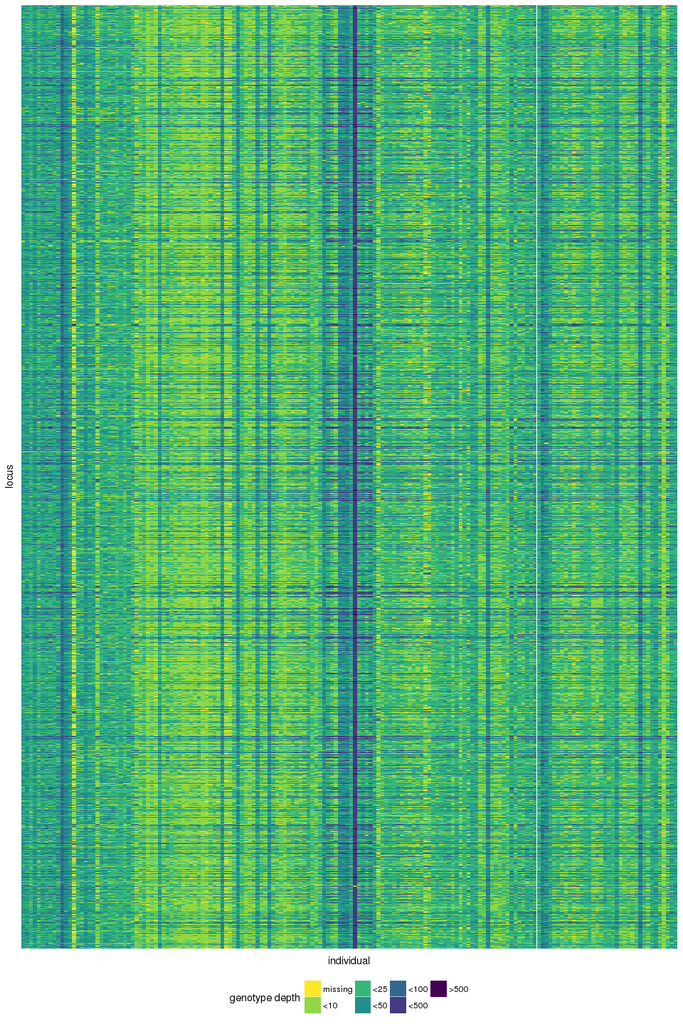

```r
# library(viridis)
ggplot(gdepth, aes(x = IND, y = LOCUS)) +
  geom_tile(aes(fill = GDEPTHBIN)) +
  scale_fill_viridis(direction = -1, option = "viridis",
                     name = 'genotype depth',
                     discrete = TRUE) +
  labs(x = "individual", y = "locus") +
  theme(axis.text.x=element_blank(),
        axis.ticks.x=element_blank(),
        axis.text.y=element_blank(),
        axis.ticks.y=element_blank(),
        legend.position="bottom")
```

### Filter 13: Excess heterozygosity

Identify SNPs with more than 0.5 heterozygosity and significant.

```r
# calculate observed heterozygosity
hwe <- read.table("data/VCF/MUN.F12.hwe",
                  stringsAsFactors = FALSE, header = TRUE) %>%
  select(-ChiSq_HWE) %>%
  separate(`OBS.HOM1.HET.HOM2.`,
           into = c("obs_hom1", "obs_het", "obs_hom2"),
           sep = "/", convert = TRUE) %>%
  separate(`E.HOM1.HET.HOM2.`,
           into = c("exp_hom1", "exp_het", "exp_hom2"),
           sep = "/", convert = TRUE) %>%
  mutate(Ho = obs_het/(obs_hom1 + obs_hom2 + obs_het),
         He = exp_het/(exp_hom1 + exp_hom2 + exp_het)) %>%
  select(CHR, POS, obs_hom1, exp_hom1, obs_hom2, exp_hom2, P_HET_DEFICIT, obs_het, exp_het, P_HET_EXCESS, Ho, He, P_HWE)
```

Distribution of observed heterozygosity.

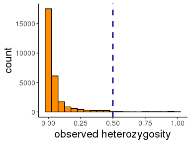

```r
ggplot(hwe, aes(x = Ho)) +
  geom_histogram(binwidth = 0.05, color = "black", fill = "darkorange") +
  geom_vline(xintercept = 0.5, color = "darkblue", linetype = "dashed", size = 1) +
  labs(x = "observed heterozygosity") +
  theme_standard
```

```r
# identify contigs with SNPs with Ho > 0.5 & significant
excess_hwe <- hwe %>%
  filter(Ho > 0.5) %>%
  mutate(p_adj = p.adjust(P_HET_EXCESS), method = "fdr") %>%
  filter(p_adj < 0.05)
contigs <- hwe %>%
  filter(CHR %in% excess_hwe$CHR) %>%
  select(CHR) %>%
  unique()
# identify all SNPs on contigs
SNPs <- hwe %>%
  filter(CHR %in% contigs$CHR) %>%
  select(CHR, POS)
View(SNPs)
# Write contig/position to text file, use file with vcftools to remove positions from dataset
write.table(SNPs, file = "data/VCF/hetexcess.loci",
            col.names= FALSE, row.names = FALSE, quote = FALSE)
```

Remove SNPs with excess heterozygosity and contigs with more than one SNP w/excess heterozygosity.

```bash
vcftools --vcf data/VCF/temp/MUN.F12.recode.vcf --out data/VCF/temp/MUN.F13 --exclude-positions data/VCF/hetexcess.loci --recode --recode-INFO-all

vcftools --vcf data/VCF/temp/MUN.F13.recode.vcf --out data/VCF/MUN.F13 --depth
vcftools --vcf data/VCF/temp/MUN.F13.recode.vcf --out data/VCF/MUN.F13 --site-mean-depth
vcftools --vcf data/VCF/temp/MUN.F13.recode.vcf --out data/VCF/MUN.F13 --missing-indv
vcftools --vcf data/VCF/temp/MUN.F13.recode.vcf --out data/VCF/MUN.F13 --missing-site
vcftools --vcf data/VCF/temp/MUN.F13.recode.vcf --out data/VCF/MUN.F13 --het
```

Visualize stats:

```r
# load stats files ----
ind_stats_F13 <- read.ind.stats(dir = "data/VCF", vcf = "MUN.F13") %>%
  separate(INDV, into = c("SP", "LIB", "SAMPLE_ID"), sep = "_", remove = FALSE)
loc_stats_F13 <- read.loc.stats(dir = "data/VCF/", vcf = "MUN.F13")
```

Data set contains 50045 SNP sites and 168 individuals.

### Filter 14: Missing data by population

```bash
# population AFL
vcftools --vcf data/VCF/temp/MUN.F13.recode.vcf --out data/VCF/temp/AFL --keep data/VCF/Ind_AFL  --recode --recode-INFO-all
vcftools --vcf data/VCF/temp/AFL.recode.vcf --out data/VCF/AFL --missing-site

# population BSL
vcftools --vcf data/VCF/temp/MUN.F13.recode.vcf --out data/VCF/temp/BSL --keep data/VCF/Ind_BSL  --recode --recode-INFO-all
vcftools --vcf data/VCF/temp/BSL.recode.vcf --out data/VCF/BSL --missing-site

# population JKF
vcftools --vcf data/VCF/temp/MUN.F13.recode.vcf --out data/VCF/temp/JKF --keep data/VCF/Ind_JKF  --recode --recode-INFO-all
vcftools --vcf data/VCF/temp/JKF.recode.vcf --out data/VCF/JKF --missing-site

# population SLT
vcftools --vcf data/VCF/temp/MUN.F13.recode.vcf --out data/VCF/temp/SLT --keep data/VCF/Ind_SLT  --recode --recode-INFO-all
vcftools --vcf data/VCF/temp/SLT.recode.vcf --out data/VCF/SLT --missing-site

# population ULM
vcftools --vcf data/VCF/temp/MUN.F13.recode.vcf --out data/VCF/temp/ULM --keep data/VCF/Ind_ULM  --recode --recode-INFO-all
vcftools --vcf data/VCF/temp/ULM.recode.vcf --out data/VCF/ULM --missing-site
```

Compare missing data per sample location (population):

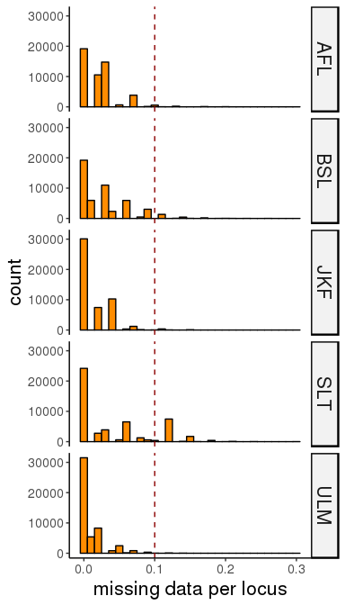

```r
# create empty list
loc_missing <- list()
# import missing data per locus
loc_missing[[1]] <- read.table("data/VCF/AFL.lmiss",
                        header = TRUE, stringsAsFactors = FALSE) %>%
  select(CHR, POS, F_MISS) %>%
  mutate(POP = "AFL")
loc_missing[[2]] <- read.table("data/VCF/BSL.lmiss",
                        header = TRUE, stringsAsFactors = FALSE) %>%
  select(CHR, POS, F_MISS) %>%
  mutate(POP = "BSL")
loc_missing[[3]] <- read.table("data/VCF/JKF.lmiss",
                        header = TRUE, stringsAsFactors = FALSE) %>%
  select(CHR, POS, F_MISS) %>%
  mutate(POP = "JKF")
loc_missing[[4]] <- read.table("data/VCF/SLT.lmiss",
                        header = TRUE, stringsAsFactors = FALSE) %>%
  select(CHR, POS, F_MISS) %>%
  mutate(POP = "SLT")
loc_missing[[5]] <- read.table("data/VCF/ULM.lmiss",
                        header = TRUE, stringsAsFactors = FALSE) %>%
  select(CHR, POS, F_MISS) %>%
  mutate(POP = "ULM")
# create data frame with all information
loc_missing <- ldply(loc_missing, data.frame)
ggplot(loc_missing, aes(x = F_MISS)) +
  geom_histogram(binwidth = .01, color = "black", fill = "darkorange") +
  geom_vline(xintercept = 0.1, color = "darkred", linetype = "dashed", size = 0.5) +
  labs(x = "missing data per locus") +
  facet_grid(POP ~ .) +
  theme_standard
```

Identify loci with high missing data in each region (genotype call rate <90%).

```r
# identify loci with high missing data in each region
SNPs <- filter(loc_missing, F_MISS > 0.1)
count(SNPs, POP)
```

| POP | n |
| --- | --- |
| AFL | 416 |
| BSL | 2112 |
| JKF | 572 |
| SLT | 9856 |
| ULM | 175 |

```r
SNPs <- SNPs %>%
  select(CHR, POS)
# Write contig/position to text file, use file with vcftools to remove positions from dataset
write.table(SNPs, file = "data/VCF/LQ_F14.loci",
            col.names= FALSE, row.names = FALSE, quote = FALSE)
```

Remove loci from data set:

```bash
vcftools --vcf data/VCF/temp/MUN.F13.recode.vcf --out data/VCF/temp/MUN.F14 --exclude-positions data/VCF/LQ_F14.loci --max-missing 0.9 --recode --recode-INFO-all

vcftools --vcf data/VCF/temp/MUN.F14.recode.vcf --out data/VCF/MUN.F14 --depth
vcftools --vcf data/VCF/temp/MUN.F14.recode.vcf --out data/VCF/MUN.F14 --site-mean-depth
vcftools --vcf data/VCF/temp/MUN.F14.recode.vcf --out data/VCF/MUN.F14 --missing-indv
vcftools --vcf data/VCF/temp/MUN.F14.recode.vcf --out data/VCF/MUN.F14 --missing-site
vcftools --vcf data/VCF/temp/MUN.F14.recode.vcf --out data/VCF/MUN.F14 --het
vcftools --vcf data/VCF/temp/MUN.F14.recode.vcf --out data/VCF/MUN.F14 --singletons
vcftools --vcf data/VCF/temp/MUN.F14.recode.vcf --out data/VCF/MUN.F14 --indv-freq-burden
vcftools --vcf data/VCF/temp/MUN.F14.recode.vcf --out data/VCF/MUN.F14 --geno-depth
```

Visualize stats:

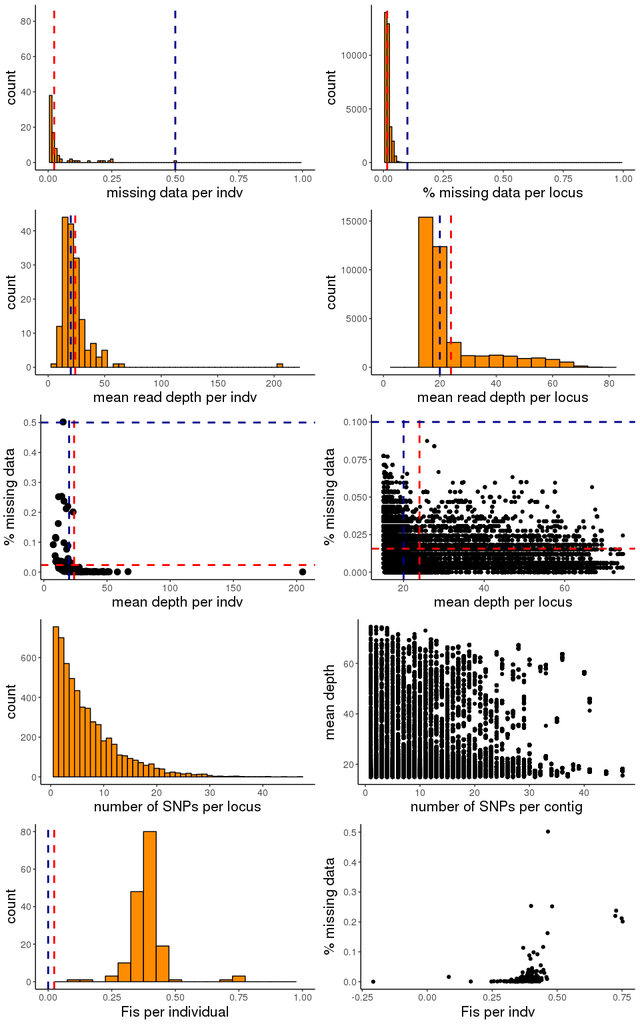

## Final thresholds values for filtered data set MUN:

- minimum sequence quality (minQ): 20
- minimum genotype call rate per locus (geno): 90%
- minimum minor allele count (mac): 3
- minimum genotype depth (minD): 3
- maximum missing data per individual (missInd): 50%
- minimum minor allele frequence (maf): 0
- mean minimum depth (m-minD): 15
- mean maximum depth (m-minD): 75
- dDocent filters run for allelic balance, Forward/Reverse and paired status, depth/quality ratio and maximum mean depth
- Indels removed from data set
- minimum genotype call rate by population: 90%

Have not yet filtered for HWE or Fis as indication of contamination

# Haplotype filtering

## Overview of haplotyping success

Comparison of the number of loci that were filtered due to excess number of missing data or suspected paralogs during the haplotyping process to those that passed. Haplotyer was run without any threshold values (other than default values). The genepop file only contains loci that passed haplotyping stage.

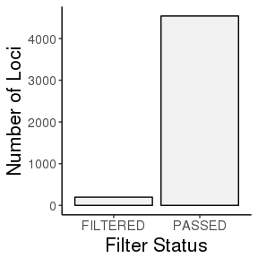

```r
# import stats files generated by haplotyper
hap_stats <- read.hap.stats("data/Haplotyping/stats.out")
hap_ind_stats <- read.delim("data/Haplotyping/ind_stats.out",
                           stringsAsFactors = FALSE)
# view comparison of filtered vs. passed loci
plot.filter.status(hap_stats)
```

Remove filtered loci from data set.

```r
count(hap_stats, Status == "FILTERED")
```

| Status == "FILTERED" | n |
| --- | --- |
| FALSE | 4540 |
| TRUE | 196 |

```r
hap_stats <- remove.filtered.haps(hap_stats)
```

4540 loci passed haplotyping process.

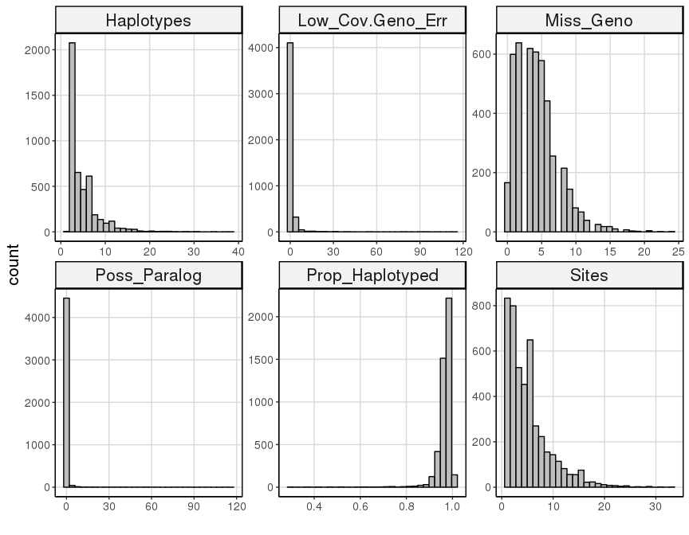

```r
plot.hap.stats(hap_stats)
```

Data set contains 168 individuals:

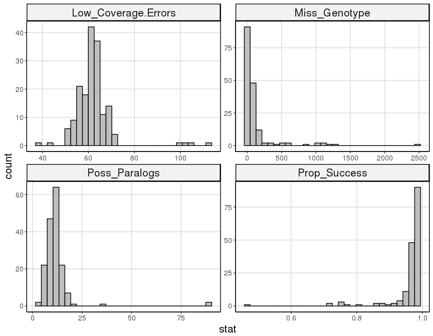

```r
plot.ind.hap.stats(hap_ind_stats)
```

## Identify threshold values to filter data set

### Proportion of individuals haplotyped

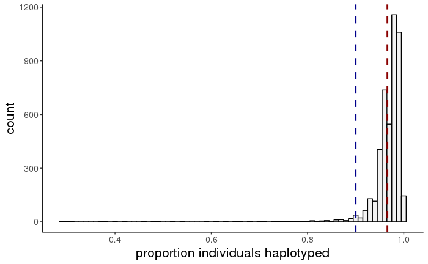

```r
ggplot(hap_stats, aes(x = Prop_Haplotyped)) +
  geom_histogram(binwidth = 0.01, color = "black", fill = "grey95") +
  geom_vline(aes(xintercept = mean(Prop_Haplotyped, na.rm = TRUE)),
                 color = "darkred", linetype = "dashed", size = 1) +
  geom_vline(aes(xintercept = 0.9),
                 color = "darkblue", linetype = "dashed", size = 1) +
  labs(x = "proportion individuals haplotyped") +
  theme_standard
```

Flag loci successfully haplotyped in < 90% of individuals.

```r
# number of loci called in >95% individuals
count(hap_stats, Prop_Haplotyped < 0.9)
```

| Prop_Haplotyped < 0.9 | n |
| --- | --- |
| FALSE | 4403 |
| TRUE | 137 |

```r
# create vector of loci to remove (choose cut-off)
Prop_Haplotyped <- filter.loci.prop_haplotyped(hap_stats, 0.9)
```

137 loci were flagged as genotype call rate < 0.9.

### Possible paralogs per locus

Loci are flagged as possible paralogs for an individuals when more than the expected number of haplotypes based on the SNP genotype call (homozygote, heterozygote) are detected.

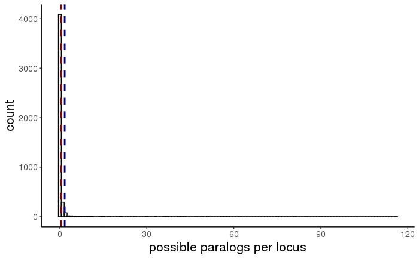

```r
ggplot(hap_stats, aes(x = Poss_Paralog)) +
  geom_histogram(binwidth = 1, color = "black", fill = "grey95") +
  geom_vline(aes(xintercept = mean(Poss_Paralog, na.rm = TRUE)),
                 color = "darkred", linetype = "dashed", size = 1) +
  geom_vline(aes(xintercept = (nrow(hap_ind_stats)*0.01)),
                 color = "darkblue", linetype = "dashed", size = 1) +
  labs(x = "possible paralogs per locus") +
  theme_standard
```

Flag loci that are flagged as potential paralogs in > 2 individuals.

```r
# number of loci with Poss_Paralogs
count(hap_stats, Poss_Paralog > 2)
```

| Poss_Paralog > 2 | n |
| --- | --- |
| FALSE | 4456 |
| TRUE | 84 |

```r
# create vector of loci to remove (choose cut-off)
Poss_Paralogs <- filter.loci.paralogs(hap_stats, 2)
```

84 loci were flagged as possible paralogs.

### Number of SNPs & Haplotypes per locus

Each locus varies in the number of SNPs detected which determines the number of haplotypes expected in that population.

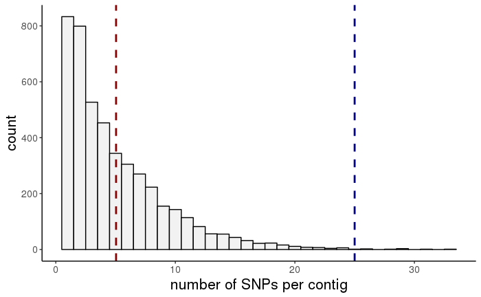

```r
ggplot(hap_stats, aes(x = Sites)) +
  geom_histogram(binwidth = 1, color = "black", fill = "grey95") +
  geom_vline(aes(xintercept = mean(Sites, na.rm = TRUE)),
                 color = "darkred", linetype = "dashed", size = 1) +
  geom_vline(aes(xintercept = 25),
                 color = "darkblue", linetype = "dashed", size = 1) +
  labs(x = "number of SNPs per contig") +
  theme_standard
```

Filtering loci based on number of SNPs contained on that locus could bias the data set as loci with high recombination may be removed. On the other hand, assuming an approximate length of 250 bp loci with more than 25 SNPs would mean that 10% of bases are a polymorphisms.

Notice that with higher number of SNP sites, loci also more probable to have been flagged as possible paralogs in multiple individuals (intersect seems to be around 15?).

```r
count(hap_stats, Sites > 25)
```

| Sites > 25 | n |
| --- | --- |
| FALSE | 4532 |
| TRUE | 8 |

```r
NoSNps <- filter.loci.noSNPs(hap_stats, 25)
```

8 loci were flagged.

Assuming that mutation is the only mechanism resulting in new haplotypes, the maximum expected number of haplotypes per locus is number of SNPs N + 1.

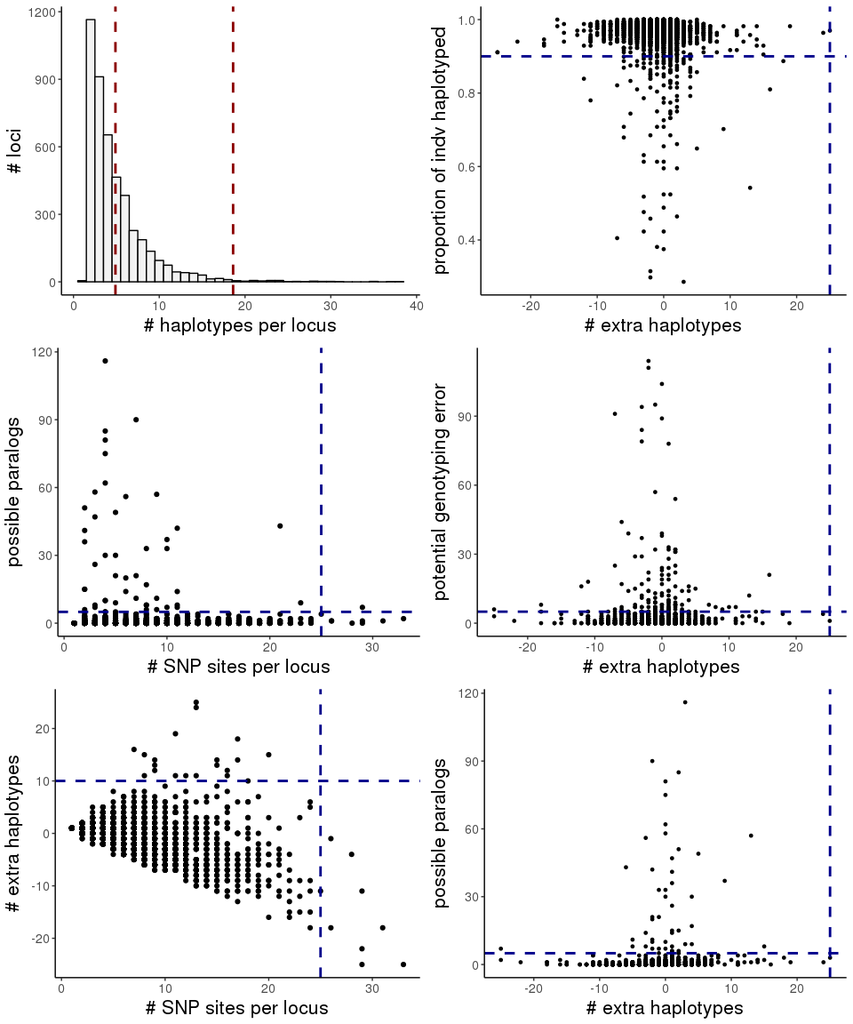

```r
p1 <- ggplot(hap_stats, aes(x = Haplotypes)) +
  geom_histogram(binwidth = 1, color = "black", fill = "grey95") +
  geom_vline(aes(xintercept = mean(Haplotypes, na.rm = TRUE)),
                 color = "darkred", linetype = "dashed", size = 1) +
  geom_vline(aes(xintercept = quantile(Haplotypes, .99)),
                 color = "darkred", linetype = "dashed", size = 1) +
  labs(x = "# haplotypes per locus", y = "# loci") +
  theme_standard
temp <- hap_stats %>%
  select(Locus, Sites, Haplotypes, Prop_Haplotyped, Low_Cov.Geno_Err, Poss_Paralog) %>%
  mutate(exp_sites = Sites + 1) %>%
  mutate(xtra = Haplotypes - Sites)
p2 <- ggplot(temp, aes(x = Sites, y = Poss_Paralog)) +
  geom_point() +
  geom_hline(yintercept = 5, color = "darkblue", linetype = "dashed", size = 1) +
  geom_vline(xintercept = 25, color = "darkblue", linetype = "dashed", size = 1) +
  labs(x = "# SNP sites per locus", y = "possible paralogs") +
  theme_standard
p3 <- ggplot(temp, aes(x = Sites, y = xtra)) +
  geom_point() +
  geom_hline(yintercept = 10, color = "darkblue", linetype = "dashed", size = 1) +
  geom_vline(xintercept = 25, color = "darkblue", linetype = "dashed", size = 1) +
  labs(x = "# SNP sites per locus", y = "# extra haplotypes") +
  theme_standard
p4 <- ggplot(temp, aes(x = xtra, y = Prop_Haplotyped)) +
  geom_point(size = 1) +
  geom_hline(yintercept = 0.9, color = "darkblue", linetype = "dashed", size = 1) +
  geom_vline(xintercept = 25, color = "darkblue", linetype = "dashed", size = 1) +
  labs(x = "# extra haplotypes", y = "proportion of indv haplotyped") +
  theme_standard
p5 <- ggplot(temp, aes(x = xtra, y = Low_Cov.Geno_Err)) +
  geom_point(size = 1) +
  geom_hline(yintercept = 5, color = "darkblue", linetype = "dashed", size = 1) +
  geom_vline(xintercept = 25, color = "darkblue", linetype = "dashed", size = 1) +
  labs(x = "# extra haplotypes", y = "potential genotyping error") +
  theme_standard
p6 <- ggplot(temp, aes(x = xtra, y = Poss_Paralog)) +
  geom_point(size = 1) +
  geom_hline(yintercept = 5, color = "darkblue", linetype = "dashed", size = 1) +
  geom_vline(xintercept = 25, color = "darkblue", linetype = "dashed", size = 1) +
  labs(x = "# extra haplotypes", y = "possible paralogs") +
  theme_standard
m21 <- multiplot(p1, p2, p3, p4, p5, p6, cols = 2)
```

Again, removing loci with unexpectedly high numbers of haplotypes may bias the data set, as loci with e.g. high recombination may be removed from the data set.

```r
count(temp, xtra >= 10)
```

| xtra >= 10 | n |
| --- | --- |
| FALSE | 4520 |
| TRUE | 20 |

```r
# create vector of loci to remove
NoHaps <- filter(temp, xtra >= 10)
NoHaps <- NoHaps$Locus
```

20 loci were flagged for excessive number of haplotypes compared to the number of SNPs at that locus.

### Low Coverage/Genotyping Error

After combining SNPs on the same contig during the haplotyping process, it is possible to observe fewer than the expected number of haplotypes based on the genotype call (heterozygote/homozygote). When this occurs, that genotype is coded as missing. For each locus the number of individuals for which is it flagged as a potential a potential genotyping error or suffering from null alleles due to low coverage detected for a given locus is recorded.

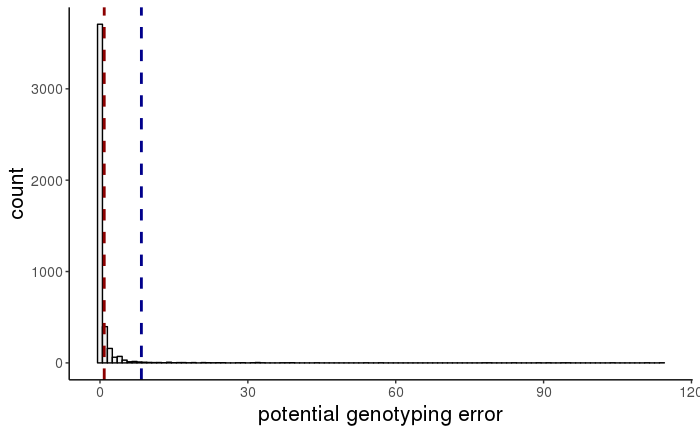

```r
ggplot(hap_stats, aes(x = Low_Cov.Geno_Err)) +
  geom_histogram(binwidth = 1, color = "black", fill = "grey95") +
  geom_vline(aes(xintercept = mean(Low_Cov.Geno_Err, na.rm = TRUE)),
                 color = "darkred", linetype = "dashed", size = 1) +
  geom_vline(aes(xintercept = (nrow(hap_ind_stats)*0.05)),
                 color = "darkblue", linetype = "dashed", size = 1) +
  labs(x = "potential genotyping error") +
  theme_standard
```

```r
# summary of count of possible genotyping errors
count(hap_stats, Low_Cov.Geno_Err > 2)
```

| Low_Cov.Geno_Err > 2 | n |
| --- | --- |
| FALSE | 4262 |
| TRUE | 278 |

```r
# create vector of loci to remove
Geno_Err <- filter.loci.geno_err(hap_stats, 2)
```

278 loci were flagged as potentially affected by genotyping error.

### Flag problematic individuals

Loci that are not successfully haplotyped in an individual due to missing data, complex locus, haplotyped genotype is higher/lower than SNP haplotype in a given individual are coded as missing for that individual. Problematic individual can be identified as having an increased amount of missing data.

**Individuals with low proportion of successfully haplotyped loci**

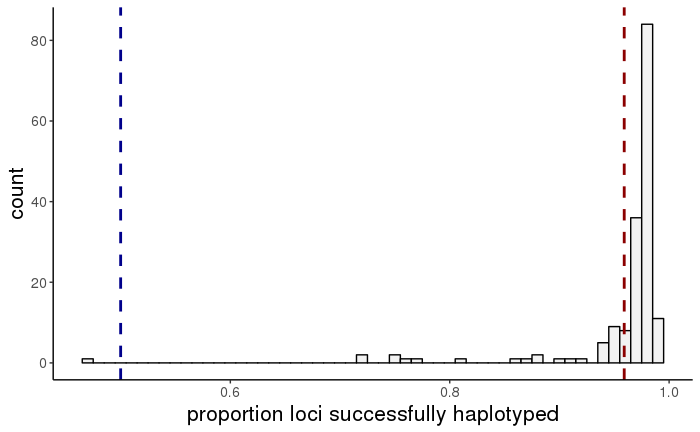

```r
ggplot(hap_ind_stats, aes(x = Prop_Success)) +
  geom_histogram(binwidth = 0.01, color = "black", fill = "grey95") +
  geom_vline(aes(xintercept = mean(Prop_Success, na.rm = TRUE)),
                 color = "darkred", linetype = "dashed", size = 1) +
  geom_vline(aes(xintercept = 0.5),
                 color = "darkblue", linetype = "dashed", size = 1) +
  labs(x = "proportion loci successfully haplotyped") +
  theme_standard
```

Problem individuals can be identified by choosing a cut-off value for the minium proportion of sucessfully haplotyped loci and excluding individuals below that threshold value.

```r
# count individuals above set threshold
count(hap_ind_stats, Prop_Success < .8)
```

| Prop_Success < 0.8 | n |
| --- | --- |
| FALSE | 161 |
| TRUE | 7 |

```r
# create vector of indv to remove (choose cut-off)
PropSuccessInd <- filter.ind.prop_success(hap_ind_stats, .8)
write.table(PropSuccessInd, "results/propSucc.indv",
            col.names = TRUE, row.names = FALSE, quote = FALSE, sep = "\t")
View(as.data.frame(PropSuccessInd))
```

**Possible paralogs per individual**

Individuals with high proportion of loci flagged as possible paralogs should be flagged as potential problem individuals.

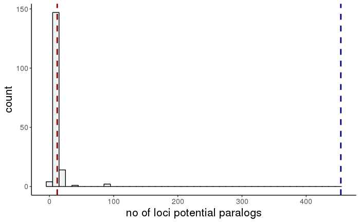

```r
ggplot(hap_ind_stats, aes(x = Poss_Paralogs)) +
  geom_histogram(binwidth = 10, color = "black", fill = "grey95") +
  geom_vline(aes(xintercept = mean(Poss_Paralogs, na.rm = TRUE)),
                 color = "darkred", linetype = "dashed", size = 1) +
  geom_vline(aes(xintercept = (nrow(hap_stats)*0.10)),
                 color = "darkblue", linetype = "dashed", size = 1) +
  labs(x = "no of loci potential paralogs") +
  theme_standard
```

Cut-off for individuals with loci flagged paralogs in > 10% of loci is 454.

```r
# count individuals above set threshold
count(hap_ind_stats, Poss_Paralogs > 85)
```

| Poss_Paralogs > 85 | n |
| --- | --- |
| FALSE | 166 |
| TRUE | 2 |

```r
# create vector of indv to remove (choose cut-off)
Poss_ParalogInd <- filter.ind.paralogs(hap_ind_stats, 85)
write.table(Poss_ParalogInd, "results/possParal.indv",
            col.names = TRUE, row.names = FALSE, quote = FALSE, sep = "\t")
View(as.data.frame(Poss_ParalogInd))
```

The highest number of flagged loci in an individuals is 90, which is equivalent to 1.98% of loci.

**Individuals with high proportion of potential allele dropout/genotyping error**

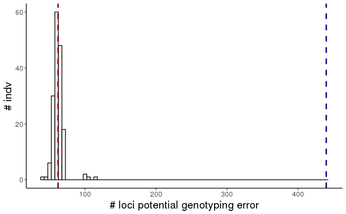

```r
ggplot(hap_ind_stats, aes(x = Low_Coverage.Errors)) +
  geom_histogram(binwidth = 5, color = "black", fill = "grey95") +
  geom_vline(aes(xintercept = mean(Low_Coverage.Errors, na.rm = TRUE)),
                 color = "darkred", linetype = "dashed", size = 1) +
  geom_vline(aes(xintercept = 440),
                 color = "darkblue", linetype = "dashed", size = 1) +
  labs(x = "# loci potential genotyping error", y = "# indv") +
  theme_standard
```

Remove individuals with high proportion of loci that have been flagged as potential allele dropouts/genotyping error.

```r
# count individuals above set threshold
count(hap_ind_stats, Low_Coverage.Errors > 454)
```

| Low_Coverage.Errors > 454 | n |
| --- | --- |
| FALSE | 168 |

```r
# create vector of indv to remove (choose cut-off)
GenoErrIndv <- filter.ind.geno_err(hap_ind_stats, 454)
write.table(GenoErrIndv, "results/GenoErr.indv",
            col.names = TRUE, row.names = FALSE, quote = FALSE, sep = "\t")
```

The highest number of flagged loci in an individuals is 113, which is equivalent to 2.49% of loci.

## Filter flagged loci and individuals as necessary

Load genepop file with haplotyped loci.

```r
# import genepop file
gen <- read.genepop(file = "data/Haplotyping/Croaker2.gen",
                    ncode = 3L, quiet = FALSE)
```

```
 Converting data from a Genepop .gen file to a genind object...


File description:  Croaker2.genepop

...done.
```

```r
gen
```

```
/// GENIND OBJECT /////////

 // 168 individuals; 4,540 loci; 22,208 alleles; size: 18.5 Mb

 // Basic content
   @tab:  168 x 22208 matrix of allele counts
   @loc.n.all: number of alleles per locus (range: 1-38)
   @loc.fac: locus factor for the 22208 columns of @tab
   @all.names: list of allele names for each locus
   @ploidy: ploidy of each individual  (range: 2-2)
   @type:  codom
   @call: read.genepop(file = "data/Haplotyping/Croaker2.gen", ncode = 3L,
    quiet = FALSE)

 // Optional content
   @pop: population of each individual (group size range: 27-43)
```

```r
# remove flagged loci
removeloc <- c(Poss_Paralogs, NoSNps, NoHaps, Geno_Err, Prop_Haplotyped)
gen <- genind.rem.loci(gen, removeloc)
# # remove flagged individuals
removeInd <- c(Poss_ParalogInd, PropSuccessInd, GenoErrIndv)
gen <- gen.ind.rem.Ind(gen, removeInd)
# # remove individuals with low proportion haplotyped individuals (< 80% genotyped)
# removeInd <- PropSuccessInd
# gen <- gen.ind.rem.Ind(gen, removeInd)
gen
```

```
/// GENIND OBJECT /////////

 // 159 individuals; 4,182 loci; 19,084 alleles; size: 15.3 Mb

 // Basic content
   @tab:  159 x 19084 matrix of allele counts
   @loc.n.all: number of alleles per locus (range: 2-30)
   @loc.fac: locus factor for the 19084 columns of @tab
   @all.names: list of allele names for each locus
   @ploidy: ploidy of each individual  (range: 2-2)
   @type:  codom
   @call: .local(x = x, i = i, j = j, drop = drop)

 // Optional content
   @pop: population of each individual (group size range: 25-42)
```